# Exp2

takashi tsukimoto

2023-06-29

```r
#ex2.csvは，スピリチュアリティ尺度の項目4について反転処理済み。
ex2.data = read.csv("ex2.csv", stringsAsFactors = TRUE)
```

## 心身二元論尺度（の下位尺度）の $\alpha$ 係数

```r
library(psych)
alpha(ex2.data[, c("D1", "D3", "D5", "D7", "D9")])
```

```
##
## Reliability analysis
## Call: alpha(x = ex2.data[, c("D1", "D3", "D5", "D7", "D9")])
##
##   raw_alpha std.alpha G6(smc) average_r S/N   ase mean  sd median_r
##       0.78      0.79    0.81      0.42 3.7 0.046  4.5 1.2     0.39
##
##     95% confidence boundaries
##          lower alpha upper
## Feldt     0.68  0.78  0.86
## Duhachek  0.69  0.78  0.87
##
##  Reliability if an item is dropped:
##    raw_alpha std.alpha G6(smc) average_r S/N alpha se var.r med.r
## D1      0.79      0.79    0.80      0.49 3.8    0.046 0.024  0.45
## D3      0.73      0.73    0.72      0.41 2.8    0.056 0.025  0.41
## D5      0.75      0.76    0.77      0.44 3.1    0.055 0.035  0.45
## D7      0.69      0.70    0.69      0.37 2.3    0.068 0.034  0.31
## D9      0.74      0.74    0.71      0.41 2.8    0.055 0.017  0.39
##
##  Item statistics
##     n raw.r std.r r.cor r.drop mean  sd
## D1 60  0.65  0.63  0.49   0.42  4.4 1.9
## D3 60  0.74  0.76  0.71   0.58  4.9 1.6
## D5 60  0.71  0.71  0.60   0.53  4.8 1.7
## D7 60  0.83  0.83  0.79   0.71  3.7 1.7
## D9 60  0.72  0.75  0.71   0.57  4.6 1.5
##
## Non missing response frequency for each item
##       1    2    3    4    5    6    7 miss
## D1 0.03 0.22 0.13 0.03 0.27 0.18 0.13    0
## D3 0.02 0.12 0.13 0.02 0.22 0.40 0.10    0
## D5 0.03 0.13 0.12 0.02 0.25 0.35 0.10    0
## D7 0.08 0.27 0.15 0.08 0.23 0.17 0.02    0
## D9 0.00 0.13 0.15 0.07 0.38 0.20 0.07    0
```

```r
alpha(ex2.data[, c("D2", "D4", "D6", "D8", "D10")])
```

```
##
## Reliability analysis
## Call: alpha(x = ex2.data[, c("D2", "D4", "D6", "D8", "D10")])
##
##   raw_alpha std.alpha G6(smc) average_r S/N   ase mean  sd median_r
##       0.76      0.77    0.77      0.41 3.4 0.051  4.1 1.2     0.46
##
##     95% confidence boundaries
##          lower alpha upper
## Feldt     0.65  0.76  0.84
## Duhachek  0.66  0.76  0.86
##
##  Reliability if an item is dropped:
##     raw_alpha std.alpha G6(smc) average_r S/N alpha se  var.r med.r
## D2       0.69      0.71    0.69      0.38 2.5    0.068 0.0368  0.38
## D4       0.66      0.68    0.64      0.35 2.1    0.074 0.0285  0.34
## D6       0.69      0.71    0.68      0.38 2.4    0.068 0.0281  0.40
## D8       0.71      0.73    0.71      0.40 2.7    0.064 0.0343  0.39
## D10      0.82      0.82    0.79      0.53 4.5    0.039 0.0069  0.50
##
##  Item statistics
##      n raw.r std.r r.cor r.drop mean  sd
## D2  60  0.75  0.77  0.69   0.60  4.5 1.6
## D4  60  0.81  0.82  0.80   0.69  4.3 1.5
## D6  60  0.76  0.77  0.72   0.60  3.8 1.6
## D8  60  0.73  0.74  0.65   0.55  4.2 1.6
## D10 60  0.57  0.53  0.32   0.28  3.8 2.0
##
## Non missing response frequency for each item
##        1    2    3    4    5    6    7 miss
## D2  0.02 0.13 0.17 0.10 0.27 0.27 0.05    0
## D4  0.03 0.13 0.13 0.17 0.30 0.20 0.03    0
## D6  0.03 0.22 0.27 0.10 0.23 0.12 0.03    0
## D8  0.03 0.17 0.17 0.18 0.22 0.15 0.08    0
## D10 0.10 0.28 0.08 0.07 0.23 0.13 0.10    0
```

物質性が $\alpha = .78$，非物質性が $\alpha = .76$ ということで，それぞれの5項目の平均値を尺度得点とする。

## スピリチュアリティ尺度の $\alpha$ 係数

```r
alpha(ex2.data[, c("S1", "S2", "S3", "S4", "S5", "S6", "S7")])
```

```
##
## Reliability analysis
## Call: alpha(x = ex2.data[, c("S1", "S2", "S3", "S4", "S5", "S6", "S7")])
##
##   raw_alpha std.alpha G6(smc) average_r S/N   ase mean   sd median_r
##       0.82      0.81    0.83      0.38 4.3 0.035  3.1 0.91     0.41
##
##     95% confidence boundaries
##          lower alpha upper
## Feldt     0.74  0.82  0.88
## Duhachek  0.75  0.82  0.88
##
##  Reliability if an item is dropped:
##    raw_alpha std.alpha G6(smc) average_r S/N alpha se var.r med.r
## S1      0.81      0.80    0.81      0.41 4.1    0.037 0.036  0.42
## S2      0.76      0.76    0.78      0.34 3.2    0.046 0.036  0.34
## S3      0.77      0.76    0.76      0.34 3.1    0.045 0.031  0.34
## S4      0.84      0.84    0.84      0.46 5.1    0.032 0.021  0.43
## S5      0.80      0.80    0.81      0.40 3.9    0.038 0.037  0.41
## S6      0.76      0.75    0.76      0.34 3.1    0.047 0.028  0.36
## S7      0.79      0.79    0.80      0.38 3.7    0.040 0.036  0.42
##
##  Item statistics
##     n raw.r std.r r.cor r.drop mean  sd
## S1 60  0.60  0.61  0.53   0.45  3.5 1.2
## S2 60  0.81  0.80  0.78   0.70  3.0 1.5
## S3 60  0.81  0.81  0.80   0.73  3.2 1.2
## S4 60  0.41  0.43  0.27   0.25  3.0 1.2
## S5 60  0.64  0.64  0.55   0.50  2.9 1.3
## S6 60  0.83  0.82  0.82   0.74  3.1 1.4
## S7 60  0.69  0.68  0.62   0.55  2.8 1.4
##
## Non missing response frequency for each item
##       1    2    3    4    5 miss
## S1 0.03 0.30 0.07 0.37 0.23    0
## S2 0.23 0.22 0.08 0.27 0.20    0
## S3 0.10 0.20 0.15 0.47 0.08    0
## S4 0.13 0.22 0.28 0.30 0.07    0
## S5 0.17 0.32 0.05 0.38 0.08    0
## S6 0.20 0.18 0.10 0.35 0.17    0
## S7 0.20 0.33 0.05 0.30 0.12    0
```

$\alpha = .82$ ということで，7項目（反転処理含む）の平均値を尺度得点とする。

## 重回帰分析

```r
#中心化
ex2.data = data.frame(
  ex2.data,
  cMAT = ex2.data$MAT - mean(ex2.data$MAT),
  cNMAT = ex2.data$NMAT - mean(ex2.data$NMAT),
  cSPI = ex2.data$SPI - mean(ex2.data$SPI)
)
model.P0MNS = lm(VISIT ~ prime01 * cMAT * cNMAT * cSPI, data = ex2.data)
summary(model.P0MNS)
```

```
##
## Call:
## lm(formula = VISIT ~ prime01 * cMAT * cNMAT * cSPI, data = ex2.data)
##
## Residuals:
##     Min      1Q  Median      3Q     Max
## -1.1775 -0.3609 -0.0792  0.4415  1.8732
##
## Coefficients:
##                         Estimate Std. Error t value Pr(>|t|)
## (Intercept)              2.32827    0.15892  14.651   <2e-16 ***
## prime01                 -0.18995    0.23479  -0.809   0.4229
## cMAT                     0.01727    0.14982   0.115   0.9087
## cNMAT                   -0.04144    0.13331  -0.311   0.7574
## cSPI                     0.48449    0.20682   2.343   0.0237 *
## prime01:cMAT             0.31012    0.22035   1.407   0.1663
## prime01:cNMAT            0.17091    0.19250   0.888   0.3795
## cMAT:cNMAT              -0.06688    0.12137  -0.551   0.5844
## prime01:cSPI            -0.69638    0.26488  -2.629   0.0117 *
## cMAT:cSPI                0.14428    0.17589   0.820   0.4165
## cNMAT:cSPI               0.13887    0.17677   0.786   0.4363
## prime01:cMAT:cNMAT      -0.14781    0.16171  -0.914   0.3657
## prime01:cMAT:cSPI       -0.09986    0.23322  -0.428   0.6706
## prime01:cNMAT:cSPI       0.22455    0.22712   0.989   0.3282
## cMAT:cNMAT:cSPI          0.13298    0.12870   1.033   0.3071
## prime01:cMAT:cNMAT:cSPI -0.32203    0.15847  -2.032   0.0482 *
## ---
## Signif. codes:  0 '***' 0.001 '**' 0.01 '*' 0.05 '.' 0.1 ' ' 1
##
## Residual standard error: 0.69 on 44 degrees of freedom
## Multiple R-squared:  0.3623, Adjusted R-squared:  0.1449
## F-statistic: 1.667 on 15 and 44 DF,  p-value: 0.09464
```

スピリチュアル尺度の反転処理をちゃんとしたら，3次の交互作用が有意傾向じゃなくて有意になった！

## さあ，ここから下位検定！

```r
# まずは下位検定のための高群／低群設定
ex2.data = data.frame(
  ex2.data,
  cMAT_h = ex2.data$cMAT - sd(ex2.data$MAT),
  cMAT_l = ex2.data$cMAT + sd(ex2.data$MAT),
  cNMAT_h = ex2.data$cNMAT - sd(ex2.data$NMAT),
  cNMAT_l = ex2.data$cNMAT + sd(ex2.data$NMAT),
  cSPI_h = ex2.data$cSPI - sd(ex2.data$SPI),
  cSPI_l = ex2.data$cSPI + sd(ex2.data$SPI)
)
```

### 単純傾斜分析1-1：プライム（物質L，非物質L，スピL）

```r
model.P_MlNlSl = lm(VISIT ~ prime01 * cMAT_l * cNMAT_l * cSPI_l, data = ex2.data)
summary(model.P_MlNlSl)
```

```
##
## Call:
## lm(formula = VISIT ~ prime01 * cMAT_l * cNMAT_l * cSPI_l, data = ex2.data)
##
## Residuals:
##     Min      1Q  Median      3Q     Max
## -1.1775 -0.3609 -0.0792  0.4415  1.8732
##
## Coefficients:
##                               Estimate Std. Error t value Pr(>|t|)
## (Intercept)                    1.95595    0.30168   6.484 6.56e-08 ***
## prime01                        0.22023    0.44946   0.490   0.6266
## cMAT_l                         0.11740    0.20603   0.570   0.5717
## cNMAT_l                        0.05414    0.22822   0.237   0.8136
## cSPI_l                         0.33650    0.44582   0.755   0.4544
## prime01:cMAT_l                 0.22260    0.38202   0.583   0.5631
## prime01:cNMAT_l               -0.20396    0.31165  -0.654   0.5162
## cMAT_l:cNMAT_l                -0.18766    0.15192  -1.235   0.2233
## prime01:cSPI_l                -1.32368    0.60661  -2.182   0.0345 *
## cMAT_l:cSPI_l                 -0.01953    0.26822  -0.073   0.9423
## cNMAT_l:cSPI_l                -0.01823    0.24245  -0.075   0.9404
## prime01:cMAT_l:cNMAT_l         0.14467    0.21280   0.680   0.5002
## prime01:cMAT_l:cSPI_l          0.29683    0.34149   0.869   0.3894
## prime01:cNMAT_l:cSPI_l         0.60502    0.31257   1.936   0.0594 .
## cMAT_l:cNMAT_l:cSPI_l          0.13298    0.12870   1.033   0.3071
## prime01:cMAT_l:cNMAT_l:cSPI_l -0.32203    0.15847  -2.032   0.0482 *
## ---
## Signif. codes:  0 '***' 0.001 '**' 0.01 '*' 0.05 '.' 0.1 ' ' 1
##
## Residual standard error: 0.69 on 44 degrees of freedom
## Multiple R-squared:  0.3623, Adjusted R-squared:  0.1449
## F-statistic: 1.667 on 15 and 44 DF,  p-value: 0.09464
```

「◯◯_l」のところに全て0を代入すると，回帰式は $VISIT = 1.95595 + 0.22023\times prime01$ となる。この傾きは非有意。物質L，非物質L，スピLにおいて，

```r
1.95595 + 0.22023 * c(0, 1)
```

```
## [1] 1.95595 2.17618
```

前者が神経科学プライム条件，後者が心理学プライム条件の参照値（グラフ作成で使う値）となる。要するに，これらの来談意図スコアに差はないということ。

以上のように，物質／非物質／スピのHigh，Lowの組み合わせをモデル投入し，これらの変数の値を0にして，残ったプライムの偏回帰係数によって単純傾斜及びその有意性を調べる。prime01に0や1を代入すると参照値が得られる。プライムの単純傾斜分析はあと7つある…。

このように，「4変数のうち3変数を2群のいずれかに固定して，残りの変数の効果を知るために，3変数に0を代入する」という作業を繰り返すのだ！ 但し，最後に残す変数がプライムではない場合の例を1つだけ示しておくので，後は，「組み合わせの抜け落ち」がないように注意しながら，分析を進めませう。

### 単純傾斜分析1-2：プライム（物質L，非物質L，スピH）

```r
model.P_MlNlSh = lm(VISIT ~ prime01 * cMAT_l * cNMAT_l * cSPI_h, data = ex2.data)
summary(model.P_MlNlSh)
```

```
##
## Call:
## lm(formula = VISIT ~ prime01 * cMAT_l * cNMAT_l * cSPI_h, data = ex2.data)
##
## Residuals:
##     Min      1Q  Median      3Q     Max
## -1.1775 -0.3609 -0.0792  0.4415  1.8732
##
## Coefficients:
##                               Estimate Std. Error t value Pr(>|t|)
## (Intercept)                    2.56718    0.71744   3.578 0.000857 ***
## prime01                       -2.18419    1.02123  -2.139 0.038042 *
## cMAT_l                         0.08193    0.41824   0.196 0.845603
## cNMAT_l                        0.02102    0.33909   0.062 0.950862
## cSPI_h                         0.33650    0.44582   0.755 0.454401
## prime01:cMAT_l                 0.76178    0.52798   1.443 0.156156
## prime01:cNMAT_l                0.89503    0.44813   1.997 0.052003 .
## cMAT_l:cNMAT_l                 0.05389    0.18360   0.294 0.770496
## prime01:cSPI_h                -1.32368    0.60661  -2.182 0.034487 *
## cMAT_l:cSPI_h                 -0.01953    0.26822  -0.073 0.942279
## cNMAT_l:cSPI_h                -0.01823    0.24245  -0.075 0.940387
## prime01:cMAT_l:cNMAT_l        -0.44029    0.22011  -2.000 0.051660 .
## prime01:cMAT_l:cSPI_h          0.29683    0.34149   0.869 0.389440
## prime01:cNMAT_l:cSPI_h         0.60502    0.31257   1.936 0.059352 .
## cMAT_l:cNMAT_l:cSPI_h          0.13298    0.12870   1.033 0.307135
## prime01:cMAT_l:cNMAT_l:cSPI_h -0.32203    0.15847  -2.032 0.048210 *
## ---
## Signif. codes:  0 '***' 0.001 '**' 0.01 '*' 0.05 '.' 0.1 ' ' 1
##
## Residual standard error: 0.69 on 44 degrees of freedom
## Multiple R-squared:  0.3623, Adjusted R-squared:  0.1449
## F-statistic: 1.667 on 15 and 44 DF,  p-value: 0.09464
```

「◯◯_l,h」のところに全て0を代入すると，回帰式は $VISIT = 2.56718-2.18419 \times prime01$ となる。この傾きは有意。物質L，非物質L，スピHにおいて，

```r
2.56718 - 2.18419 * c(0, 1)
```

```
## [1] 2.56718 0.38299
```

来談意図に差はある！（物質L，非物質L，スピHでは，神経科学プライムの方が心理学プライムよりも来談意図が高い）

### 単純傾斜分析1-3：プライム（物質L，非物質H，スピL）

```r
model.P_MlNhSl = lm(VISIT ~ prime01 * cMAT_l * cNMAT_h * cSPI_l, data = ex2.data)
summary(model.P_MlNhSl)
```

```
##
## Call:
## lm(formula = VISIT ~ prime01 * cMAT_l * cNMAT_h * cSPI_l, data = ex2.data)
##
## Residuals:
##     Min      1Q  Median      3Q     Max
## -1.1775 -0.3609 -0.0792  0.4415  1.8732
##
## Coefficients:
##                               Estimate Std. Error t value Pr(>|t|)
## (Intercept)                    2.08933    0.41724   5.007 9.41e-06 ***
## prime01                       -0.28226    0.56173  -0.502   0.6178
## cMAT_l                        -0.34493    0.30026  -1.149   0.2569
## cNMAT_h                        0.05414    0.22822   0.237   0.8136
## cSPI_l                         0.29157    0.37049   0.787   0.4355
## prime01:cMAT_l                 0.57902    0.39070   1.482   0.1455
## prime01:cNMAT_h               -0.20396    0.31165  -0.654   0.5162
## cMAT_l:cNMAT_h                -0.18766    0.15192  -1.235   0.2233
## prime01:cSPI_l                 0.16688    0.48080   0.347   0.7302
## cMAT_l:cSPI_l                  0.30809    0.20051   1.537   0.1316
## cNMAT_h:cSPI_l                -0.01823    0.24245  -0.075   0.9404
## prime01:cMAT_l:cNMAT_h         0.14467    0.21280   0.680   0.5002
## prime01:cMAT_l:cSPI_l         -0.49655    0.26150  -1.899   0.0642 .
## prime01:cNMAT_h:cSPI_l         0.60502    0.31257   1.936   0.0594 .
## cMAT_l:cNMAT_h:cSPI_l          0.13298    0.12870   1.033   0.3071
## prime01:cMAT_l:cNMAT_h:cSPI_l -0.32203    0.15847  -2.032   0.0482 *
## ---
## Signif. codes:  0 '***' 0.001 '**' 0.01 '*' 0.05 '.' 0.1 ' ' 1
##
## Residual standard error: 0.69 on 44 degrees of freedom
## Multiple R-squared:  0.3623, Adjusted R-squared:  0.1449
## F-statistic: 1.667 on 15 and 44 DF,  p-value: 0.09464
```

「◯◯_l,h」のところに全て0を代入すると，回帰式は $VISIT = 2 .08933-0.28226 \times prime01$ となる。この傾きは非有意。物質L，非物質H，スピLにおいて，

```r
2.08933 - 0.28226 * c(0, 1)
```

```
## [1] 2.08933 1.80707
```

来談意図に差は無さそう。

### 単純傾斜分析1-4：プライム（物質L，非物質H，スピH）

```r
model.P_MlNhSh = lm(VISIT ~ prime01 * cMAT_l * cNMAT_h * cSPI_h, data = ex2.data)
summary(model.P_MlNhSh)
```

```
##
## Call:
## lm(formula = VISIT ~ prime01 * cMAT_l * cNMAT_h * cSPI_h, data = ex2.data)
##
## Residuals:
##     Min      1Q  Median      3Q     Max
## -1.1775 -0.3609 -0.0792  0.4415  1.8732
##
## Coefficients:
##                               Estimate Std. Error t value Pr(>|t|)
## (Intercept)                    2.61896    0.45539   5.751 7.83e-07 ***
## prime01                        0.02088    0.57662   0.036   0.9713
## cMAT_l                         0.21470    0.23805   0.902   0.3720
## cNMAT_h                        0.02102    0.33909   0.062   0.9509
## cSPI_h                         0.29157    0.37049   0.787   0.4355
## prime01:cMAT_l                -0.32294    0.28420  -1.136   0.2620
## prime01:cNMAT_h                0.89503    0.44813   1.997   0.0520 .
## cMAT_l:cNMAT_h                 0.05389    0.18360   0.294   0.7705
## prime01:cSPI_h                 0.16688    0.48080   0.347   0.7302
## cMAT_l:cSPI_h                  0.30809    0.20051   1.537   0.1316
## cNMAT_h:cSPI_h                -0.01823    0.24245  -0.075   0.9404
## prime01:cMAT_l:cNMAT_h        -0.44029    0.22011  -2.000   0.0517 .
## prime01:cMAT_l:cSPI_h         -0.49655    0.26150  -1.899   0.0642 .
## prime01:cNMAT_h:cSPI_h         0.60502    0.31257   1.936   0.0594 .
## cMAT_l:cNMAT_h:cSPI_h          0.13298    0.12870   1.033   0.3071
## prime01:cMAT_l:cNMAT_h:cSPI_h -0.32203    0.15847  -2.032   0.0482 *
## ---
## Signif. codes:  0 '***' 0.001 '**' 0.01 '*' 0.05 '.' 0.1 ' ' 1
##
## Residual standard error: 0.69 on 44 degrees of freedom
## Multiple R-squared:  0.3623, Adjusted R-squared:  0.1449
## F-statistic: 1.667 on 15 and 44 DF,  p-value: 0.09464
```

```r
2.61896 + 0.02088 * c(0, 1)
```

```
## [1] 2.61896 2.63984
```

来談意図に差は無い。

### 単純傾斜分析1-5：プライム（物質H，非物質L，スピL）

```r
model.P_MhNlSl = lm(VISIT ~ prime01 * cMAT_h * cNMAT_l * cSPI_l, data = ex2.data)
summary(model.P_MhNlSl)
```

```
##
## Call:
## lm(formula = VISIT ~ prime01 * cMAT_h * cNMAT_l * cSPI_l, data = ex2.data)
##
## Residuals:
##     Min      1Q  Median      3Q     Max
## -1.1775 -0.3609 -0.0792  0.4415  1.8732
##
## Coefficients:
##                               Estimate Std. Error t value Pr(>|t|)
## (Intercept)                    2.23337    0.49648   4.498 4.95e-05 ***
## prime01                        0.74622    0.87324   0.855   0.3974
## cMAT_h                         0.11740    0.20603   0.570   0.5717
## cNMAT_l                       -0.38929    0.34862  -1.117   0.2702
## cSPI_l                         0.29034    0.43270   0.671   0.5057
## prime01:cMAT_h                 0.22260    0.38202   0.583   0.5631
## prime01:cNMAT_l                0.13788    0.47030   0.293   0.7708
## cMAT_h:cNMAT_l                -0.18766    0.15192  -1.235   0.2233
## prime01:cSPI_l                -0.62231    0.55507  -1.121   0.2683
## cMAT_h:cSPI_l                 -0.01953    0.26822  -0.073   0.9423
## cNMAT_l:cSPI_l                 0.29598    0.22350   1.324   0.1922
## prime01:cMAT_h:cNMAT_l         0.14467    0.21280   0.680   0.5002
## prime01:cMAT_h:cSPI_l          0.29683    0.34149   0.869   0.3894
## prime01:cNMAT_l:cSPI_l        -0.15591    0.27491  -0.567   0.5735
## cMAT_h:cNMAT_l:cSPI_l          0.13298    0.12870   1.033   0.3071
## prime01:cMAT_h:cNMAT_l:cSPI_l -0.32203    0.15847  -2.032   0.0482 *
## ---
## Signif. codes:  0 '***' 0.001 '**' 0.01 '*' 0.05 '.' 0.1 ' ' 1
##
## Residual standard error: 0.69 on 44 degrees of freedom
## Multiple R-squared:  0.3623, Adjusted R-squared:  0.1449
## F-statistic: 1.667 on 15 and 44 DF,  p-value: 0.09464
```

```r
2.23337 + 0.74622 * c(0, 1)
```

```
## [1] 2.23337 2.97959
```

来談意図に差は無い。

### 単純傾斜分析1-6：プライム（物質H，非物質L，スピH）

```r
model.P_MhNlSh = lm(VISIT ~ prime01 * cMAT_h * cNMAT_l * cSPI_h, data = ex2.data)
summary(model.P_MhNlSh)
```

```
##
## Call:
## lm(formula = VISIT ~ prime01 * cMAT_h * cNMAT_l * cSPI_h, data = ex2.data)
##
## Residuals:
##     Min      1Q  Median      3Q     Max
## -1.1775 -0.3609 -0.0792  0.4415  1.8732
##
## Coefficients:
##                               Estimate Std. Error t value Pr(>|t|)
## (Intercept)                    2.76077    0.45903   6.014 3.22e-07 ***
## prime01                       -0.38418    0.52102  -0.737   0.4648
## cMAT_h                         0.08193    0.41824   0.196   0.8456
## cNMAT_l                        0.14836    0.21003   0.706   0.4837
## cSPI_h                         0.29034    0.43270   0.671   0.5057
## prime01:cMAT_h                 0.76178    0.52798   1.443   0.1562
## prime01:cNMAT_l               -0.14532    0.24688  -0.589   0.5591
## cMAT_h:cNMAT_l                 0.05389    0.18360   0.294   0.7705
## prime01:cSPI_h                -0.62231    0.55507  -1.121   0.2683
## cMAT_h:cSPI_h                 -0.01953    0.26822  -0.073   0.9423
## cNMAT_l:cSPI_h                 0.29598    0.22350   1.324   0.1922
## prime01:cMAT_h:cNMAT_l        -0.44029    0.22011  -2.000   0.0517 .
## prime01:cMAT_h:cSPI_h          0.29683    0.34149   0.869   0.3894
## prime01:cNMAT_l:cSPI_h        -0.15591    0.27491  -0.567   0.5735
## cMAT_h:cNMAT_l:cSPI_h          0.13298    0.12870   1.033   0.3071
## prime01:cMAT_h:cNMAT_l:cSPI_h -0.32203    0.15847  -2.032   0.0482 *
## ---
## Signif. codes:  0 '***' 0.001 '**' 0.01 '*' 0.05 '.' 0.1 ' ' 1
##
## Residual standard error: 0.69 on 44 degrees of freedom
## Multiple R-squared:  0.3623, Adjusted R-squared:  0.1449
## F-statistic: 1.667 on 15 and 44 DF,  p-value: 0.09464
```

```r
2.76077 + 0.38418 * c(0, 1)
```

```
## [1] 2.76077 3.14495
```

来談意図に差は無い。

### 単純傾斜分析1-7：プライム（物質H，非物質H，スピL）

```r
model.P_MhNhSl = lm(VISIT ~ prime01 * cMAT_h * cNMAT_h * cSPI_l, data = ex2.data)
summary(model.P_MhNhSl)
```

```
##
## Call:
## lm(formula = VISIT ~ prime01 * cMAT_h * cNMAT_h * cSPI_l, data = ex2.data)
##
## Residuals:
##     Min      1Q  Median      3Q     Max
## -1.1775 -0.3609 -0.0792  0.4415  1.8732
##
## Coefficients:
##                               Estimate Std. Error t value Pr(>|t|)
## (Intercept)                     1.2743     0.6915   1.843   0.0721 .
## prime01                         1.0859     0.7788   1.394   0.1702
## cMAT_h                         -0.3449     0.3003  -1.149   0.2569
## cNMAT_h                        -0.3893     0.3486  -1.117   0.2702
## cSPI_l                          1.0195     0.3880   2.627   0.0118 *
## prime01:cMAT_h                  0.5790     0.3907   1.482   0.1455
## prime01:cNMAT_h                 0.1379     0.4703   0.293   0.7708
## cMAT_h:cNMAT_h                 -0.1877     0.1519  -1.235   0.2233
## prime01:cSPI_l                 -1.0064     0.4505  -2.234   0.0306 *
## cMAT_h:cSPI_l                   0.3081     0.2005   1.537   0.1316
## cNMAT_h:cSPI_l                  0.2960     0.2235   1.324   0.1922
## prime01:cMAT_h:cNMAT_h          0.1447     0.2128   0.680   0.5002
## prime01:cMAT_h:cSPI_l          -0.4966     0.2615  -1.899   0.0642 .
## prime01:cNMAT_h:cSPI_l         -0.1559     0.2749  -0.567   0.5735
## cMAT_h:cNMAT_h:cSPI_l           0.1330     0.1287   1.033   0.3071
## prime01:cMAT_h:cNMAT_h:cSPI_l  -0.3220     0.1585  -2.032   0.0482 *
## ---
## Signif. codes:  0 '***' 0.001 '**' 0.01 '*' 0.05 '.' 0.1 ' ' 1
##
## Residual standard error: 0.69 on 44 degrees of freedom
## Multiple R-squared:  0.3623, Adjusted R-squared:  0.1449
## F-statistic: 1.667 on 15 and 44 DF,  p-value: 0.09464
```

「◯◯_l,h」のところに全て0を代入すると，回帰式は $VISIT = 1.2743+ 1.0859\times prime01$ となる。この傾きは非有意。物質H，非物質H，スピLにおいて，

```r
1.2743 + 1.0859 * c(0, 1)
```

```
## [1] 1.2743 2.3602
```

来談意図に差は無い。

### 単純傾斜分析1-8：プライム（物質H，非物質H，スピH）

```r
model.P_MhNhSh = lm(VISIT ~ prime01 * cMAT_h * cNMAT_h * cSPI_h, data = ex2.data)
summary(model.P_MhNhSh)
```

```
##
## Call:
## lm(formula = VISIT ~ prime01 * cMAT_h * cNMAT_h * cSPI_h, data = ex2.data)
##
## Residuals:
##     Min      1Q  Median      3Q     Max
## -1.1775 -0.3609 -0.0792  0.4415  1.8732
##
## Coefficients:
##                               Estimate Std. Error t value Pr(>|t|)
## (Intercept)                    3.12627    0.32724   9.553 2.68e-12 ***
## prime01                       -0.74220    0.41731  -1.779   0.0822 .
## cMAT_h                         0.21470    0.23805   0.902   0.3720
## cNMAT_h                        0.14836    0.21003   0.706   0.4837
## cSPI_h                         1.01955    0.38804   2.627   0.0118 *
## prime01:cMAT_h                -0.32294    0.28420  -1.136   0.2620
## prime01:cNMAT_h               -0.14532    0.24688  -0.589   0.5591
## cMAT_h:cNMAT_h                 0.05389    0.18360   0.294   0.7705
## prime01:cSPI_h                -1.00642    0.45045  -2.234   0.0306 *
## cMAT_h:cSPI_h                  0.30809    0.20051   1.537   0.1316
## cNMAT_h:cSPI_h                 0.29598    0.22350   1.324   0.1922
## prime01:cMAT_h:cNMAT_h        -0.44029    0.22011  -2.000   0.0517 .
## prime01:cMAT_h:cSPI_h         -0.49655    0.26150  -1.899   0.0642 .
## prime01:cNMAT_h:cSPI_h        -0.15591    0.27491  -0.567   0.5735
## cMAT_h:cNMAT_h:cSPI_h          0.13298    0.12870   1.033   0.3071
## prime01:cMAT_h:cNMAT_h:cSPI_h -0.32203    0.15847  -2.032   0.0482 *
## ---
## Signif. codes:  0 '***' 0.001 '**' 0.01 '*' 0.05 '.' 0.1 ' ' 1
##
## Residual standard error: 0.69 on 44 degrees of freedom
## Multiple R-squared:  0.3623, Adjusted R-squared:  0.1449
## F-statistic: 1.667 on 15 and 44 DF,  p-value: 0.09464
```

「◯◯_h」のところに全て0を代入すると，回帰式は $VISIT = 3.12627 -0.74220 \times prime01$ となる。この傾きは有意傾向。物質H，非物質H，スピHにおいて，

```r
3.12627 -0.74220 * c(0, 1)
```

```
## [1] 3.12627 2.38407
```

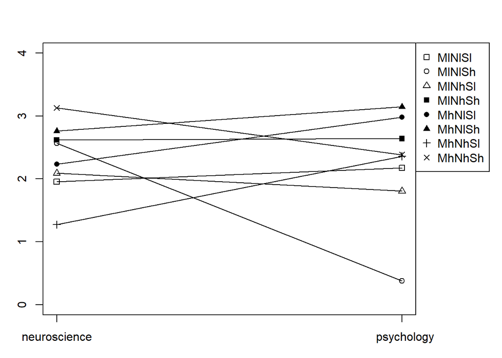

```r
x = data.frame(
    MlNlSl = c(1.95595, 2.17618),
    MlNlSh = c(2.56718, 0.38299),
    MlNhSl = c(2.08933, 1.80707),
    MlNhSh = c(2.61896, 2.63984),
    MhNlSl = c(2.23337, 2.97959),
    MhNlSh = c(2.76077, 3.14495),
    MhNhSl = c(1.2743, 2.3602),
    MhNhSh = c(3.12627,2.38407)
)
par(mar=c(3,3,3,6))

plot(0, 0, type = "n", xlim = c(0, 1), ylim = range(0, 4), xlab = "Prime", ylab = "Visit", xaxt = "n")
axis(1, at=c(0, 1), formatC(c("neuroscience", "psychology")))

pchs = c(0,1,2,15,16,17,3,4)

for (i in 1:ncol(x)) {
  points(0:1, x[, i], pch = pchs[i])
  lines(0:1, x[, i])
}
par(xpd=T)
legend(par()$usr[2], par()$usr[4], legend=colnames(x), pch = pchs)
```

```r
# legend("topright", legend = colnames(x), pch = pchs)

#X軸Y軸のラベルが反映されない。。。
```

## 単純傾斜分析2-1：物質（プラP，非物質L，スピL）

```r
model.M_PpNlsl = lm(VISIT ~ prime10 * cNMAT_l * cSPI_l * cMAT, data = ex2.data)
summary(model.M_PpNlsl)
```

```
##
## Call:
## lm(formula = VISIT ~ prime10 * cNMAT_l * cSPI_l * cMAT, data = ex2.data)
##
## Residuals:
##     Min      1Q  Median      3Q     Max
## -1.1775 -0.3609 -0.0792  0.4415  1.8732
##
## Coefficients:
##                             Estimate Std. Error t value Pr(>|t|)
## (Intercept)                  2.57788    0.41119   6.269 1.36e-07 ***
## prime10                     -0.48322    0.52781  -0.916   0.3649
## cNMAT_l                     -0.20061    0.20336  -0.986   0.3293
## cSPI_l                      -0.65957    0.28757  -2.294   0.0266 *
## cMAT                         0.34001    0.32170   1.057   0.2963
## prime10:cNMAT_l              0.03304    0.30976   0.107   0.9155
## prime10:cSPI_l               0.97299    0.41865   2.324   0.0248 *
## cNMAT_l:cSPI_l               0.36343    0.14260   2.549   0.0144 *
## prime10:cMAT                -0.22260    0.38202  -0.583   0.5631
## cNMAT_l:cMAT                -0.04299    0.14901  -0.289   0.7743
## cSPI_l:cMAT                  0.27730    0.21136   1.312   0.1963
## prime10:cNMAT_l:cSPI_l      -0.22455    0.22712  -0.989   0.3282
## prime10:cNMAT_l:cMAT        -0.14467    0.21280  -0.680   0.5002
## prime10:cSPI_l:cMAT         -0.29683    0.34149  -0.869   0.3894
## cNMAT_l:cSPI_l:cMAT         -0.18905    0.09247  -2.045   0.0469 *
## prime10:cNMAT_l:cSPI_l:cMAT  0.32203    0.15847   2.032   0.0482 *
## ---
## Signif. codes:  0 '***' 0.001 '**' 0.01 '*' 0.05 '.' 0.1 ' ' 1
##
## Residual standard error: 0.69 on 44 degrees of freedom
## Multiple R-squared:  0.3623, Adjusted R-squared:  0.1449
## F-statistic: 1.667 on 15 and 44 DF,  p-value: 0.09464
```

cMAT以外の変数に0を代入すると，モデル式は $VISIT = 2.57788+ 0.34001\times cMAT$ となる。この傾きは非有意。プライムP，非物質L，スピLにおいて，

```r
s = sd(ex2.data$MAT)
2.57788 + 0.34001 * c(-s, s)
```

```
## [1] 2.176174 2.979586
```

前者が物質L群，後者が物質H群の参照値（グラフ作成で使う値）となる。 来談意図に差は無い。

## 単純傾斜分析2-2：物質（プラP，非物質L，スピH）

```r
model.M_PpNlsh = lm(VISIT ~ prime10 * cNMAT_l * cSPI_h * cMAT, data = ex2.data)
summary(model.M_PpNlsh)
```

```
##
## Call:
## lm(formula = VISIT ~ prime10 * cNMAT_l * cSPI_h * cMAT, data = ex2.data)
##
## Residuals:
##     Min      1Q  Median      3Q     Max
## -1.1775 -0.3609 -0.0792  0.4415  1.8732
##
## Coefficients:
##                             Estimate Std. Error t value Pr(>|t|)
## (Intercept)                  1.37979    0.38668   3.568 0.000882 ***
## prime10                      1.28418    0.51776   2.480 0.017026 *
## cNMAT_l                      0.45954    0.17539   2.620 0.012020 *
## cSPI_h                      -0.65957    0.28757  -2.294 0.026647 *
## cMAT                         0.84370    0.32225   2.618 0.012077 *
## prime10:cNMAT_l             -0.37485    0.25152  -1.490 0.143258
## prime10:cSPI_h               0.97299    0.41865   2.324 0.024801 *
## cNMAT_l:cSPI_h               0.36343    0.14260   2.549 0.014382 *
## prime10:cMAT                -0.76178    0.52798  -1.443 0.156156
## cNMAT_l:cMAT                -0.38640    0.12141  -3.183 0.002678 **
## cSPI_h:cMAT                  0.27730    0.21136   1.312 0.196329
## prime10:cNMAT_l:cSPI_h      -0.22455    0.22712  -0.989 0.328206
## prime10:cNMAT_l:cMAT         0.44029    0.22011   2.000 0.051660 .
## prime10:cSPI_h:cMAT         -0.29683    0.34149  -0.869 0.389440
## cNMAT_l:cSPI_h:cMAT         -0.18905    0.09247  -2.045 0.046913 *
## prime10:cNMAT_l:cSPI_h:cMAT  0.32203    0.15847   2.032 0.048210 *
## ---
## Signif. codes:  0 '***' 0.001 '**' 0.01 '*' 0.05 '.' 0.1 ' ' 1
##
## Residual standard error: 0.69 on 44 degrees of freedom
## Multiple R-squared:  0.3623, Adjusted R-squared:  0.1449
## F-statistic: 1.667 on 15 and 44 DF,  p-value: 0.09464
```

cMAT以外の変数に0を代入すると，モデル式は $VISIT = 1.37979 + 0.84370\times cMAT$ となる。この傾きは有意。プライムP，非物質L，スピHにおいて，

```r
s = sd(ex2.data$MAT)
1.379797 + 0.84370 * c(-s, s)
```

```
## [1] 0.3830053 2.3765887
```

来談意図に差はある！（プライムP，非物質L，スピHでは，物質H群の方が物質L群よりも来談意図が高い）

## 単純傾斜分析2-3：物質（プラP，非物質H，スピL）

```r
model.M_PpNhsl = lm(VISIT ~ prime10 * cNMAT_h * cSPI_l * cMAT, data = ex2.data)
summary(model.M_PpNhsl)
```

```
##
## Call:
## lm(formula = VISIT ~ prime10 * cNMAT_h * cSPI_l * cMAT, data = ex2.data)
##
## Residuals:
##     Min      1Q  Median      3Q     Max
## -1.1775 -0.3609 -0.0792  0.4415  1.8732
##
## Coefficients:
##                             Estimate Std. Error t value Pr(>|t|)
## (Intercept)                  2.08364    0.21832   9.544 2.76e-12 ***
## prime10                     -0.40183    0.49793  -0.807   0.4240
## cNMAT_h                     -0.20061    0.20336  -0.986   0.3293
## cSPI_l                       0.23579    0.18381   1.283   0.2063
## cMAT                         0.23410    0.24999   0.936   0.3542
## prime10:cNMAT_h              0.03304    0.30976   0.107   0.9155
## prime10:cSPI_l               0.41977    0.34869   1.204   0.2351
## cNMAT_h:cSPI_l               0.36343    0.14260   2.549   0.0144 *
## prime10:cMAT                -0.57902    0.39070  -1.482   0.1455
## cNMAT_h:cMAT                -0.04299    0.14901  -0.289   0.7743
## cSPI_l:cMAT                 -0.18847    0.16787  -1.123   0.2677
## prime10:cNMAT_h:cSPI_l      -0.22455    0.22712  -0.989   0.3282
## prime10:cNMAT_h:cMAT        -0.14467    0.21280  -0.680   0.5002
## prime10:cSPI_l:cMAT          0.49655    0.26150   1.899   0.0642 .
## cNMAT_h:cSPI_l:cMAT         -0.18905    0.09247  -2.045   0.0469 *
## prime10:cNMAT_h:cSPI_l:cMAT  0.32203    0.15847   2.032   0.0482 *
## ---
## Signif. codes:  0 '***' 0.001 '**' 0.01 '*' 0.05 '.' 0.1 ' ' 1
##
## Residual standard error: 0.69 on 44 degrees of freedom
## Multiple R-squared:  0.3623, Adjusted R-squared:  0.1449
## F-statistic: 1.667 on 15 and 44 DF,  p-value: 0.09464
```

cMAT以外の変数に0を代入すると，モデル式は $VISIT = 2.08364 +0.23410\times cMAT$ となる。この傾きは非有意。プライムP，非物質H，スピLにおいて，

```r
s = sd(ex2.data$MAT)
2.08364+0.23410 * c(-s, s)
```

```
## [1] 1.807062 2.360218
```

来談意図に差は無い。

## 単純傾斜分析2-4：物質（プラP，非物質H，スピH）

```r
model.M_PpNhsh = lm(VISIT ~ prime10 * cNMAT_h * cSPI_h * cMAT, data = ex2.data)
summary(model.M_PpNhsh)
```

```
##
## Call:
## lm(formula = VISIT ~ prime10 * cNMAT_h * cSPI_h * cMAT, data = ex2.data)
##
## Residuals:
##     Min      1Q  Median      3Q     Max
## -1.1775 -0.3609 -0.0792  0.4415  1.8732
##
## Coefficients:
##                             Estimate Std. Error t value Pr(>|t|)
## (Intercept)                  2.51195    0.24989  10.052 5.68e-13 ***
## prime10                      0.36066    0.37493   0.962  0.34134
## cNMAT_h                      0.45954    0.17539   2.620  0.01202 *
## cSPI_h                       0.23579    0.18381   1.283  0.20627
## cMAT                        -0.10824    0.15525  -0.697  0.48933
## prime10:cNMAT_h             -0.37485    0.25152  -1.490  0.14326
## prime10:cSPI_h               0.41977    0.34869   1.204  0.23509
## cNMAT_h:cSPI_h               0.36343    0.14260   2.549  0.01438 *
## prime10:cMAT                 0.32294    0.28420   1.136  0.26198
## cNMAT_h:cMAT                -0.38640    0.12141  -3.183  0.00268 **
## cSPI_h:cMAT                 -0.18847    0.16787  -1.123  0.26766
## prime10:cNMAT_h:cSPI_h      -0.22455    0.22712  -0.989  0.32821
## prime10:cNMAT_h:cMAT         0.44029    0.22011   2.000  0.05166 .
## prime10:cSPI_h:cMAT          0.49655    0.26150   1.899  0.06416 .
## cNMAT_h:cSPI_h:cMAT         -0.18905    0.09247  -2.045  0.04691 *
## prime10:cNMAT_h:cSPI_h:cMAT  0.32203    0.15847   2.032  0.04821 *
## ---
## Signif. codes:  0 '***' 0.001 '**' 0.01 '*' 0.05 '.' 0.1 ' ' 1
##
## Residual standard error: 0.69 on 44 degrees of freedom
## Multiple R-squared:  0.3623, Adjusted R-squared:  0.1449
## F-statistic: 1.667 on 15 and 44 DF,  p-value: 0.09464
```

cMAT以外の変数に0を代入すると，モデル式は $VISIT = 2.51195 - 0.10824\times cMAT$ となる。この傾きは非有意。プライムP，非物質H，スピHにおいて，

```r
s = sd(ex2.data$MAT)
2.51195 - 0.10824 * c(-s, s)
```

```
## [1] 2.63983 2.38407
```

来談意図に差は無い。

## 単純傾斜分析2-5：物質（プラN，非物質L，スピL）

```r
model.M_PnNlsl = lm(VISIT ~ prime01 * cNMAT_l * cSPI_l * cMAT, data = ex2.data)
summary(model.M_PnNlsl)
```

```
##
## Call:
## lm(formula = VISIT ~ prime01 * cNMAT_l * cSPI_l * cMAT, data = ex2.data)
##
## Residuals:
##     Min      1Q  Median      3Q     Max
## -1.1775 -0.3609 -0.0792  0.4415  1.8732
##
## Coefficients:
##                             Estimate Std. Error t value Pr(>|t|)
## (Intercept)                  2.09466    0.33091   6.330  1.1e-07 ***
## prime01                      0.48322    0.52781   0.916   0.3649
## cNMAT_l                     -0.16757    0.23365  -0.717   0.4771
## cSPI_l                       0.31342    0.30426   1.030   0.3086
## cMAT                         0.11740    0.20603   0.570   0.5717
## prime01:cNMAT_l             -0.03304    0.30976  -0.107   0.9155
## prime01:cSPI_l              -0.97299    0.41865  -2.324   0.0248 *
## cNMAT_l:cSPI_l               0.13887    0.17677   0.786   0.4363
## prime01:cMAT                 0.22260    0.38202   0.583   0.5631
## cNMAT_l:cMAT                -0.18766    0.15192  -1.235   0.2233
## cSPI_l:cMAT                 -0.01953    0.26822  -0.073   0.9423
## prime01:cNMAT_l:cSPI_l       0.22455    0.22712   0.989   0.3282
## prime01:cNMAT_l:cMAT         0.14467    0.21280   0.680   0.5002
## prime01:cSPI_l:cMAT          0.29683    0.34149   0.869   0.3894
## cNMAT_l:cSPI_l:cMAT          0.13298    0.12870   1.033   0.3071
## prime01:cNMAT_l:cSPI_l:cMAT -0.32203    0.15847  -2.032   0.0482 *
## ---
## Signif. codes:  0 '***' 0.001 '**' 0.01 '*' 0.05 '.' 0.1 ' ' 1
##
## Residual standard error: 0.69 on 44 degrees of freedom
## Multiple R-squared:  0.3623, Adjusted R-squared:  0.1449
## F-statistic: 1.667 on 15 and 44 DF,  p-value: 0.09464
```

cMAT以外の変数に0を代入すると，モデル式は $VISIT = 2.09466 + 0.11740\times cMAT$ となる。この傾きは非有意。プライムN，非物質L，スピLにおいて，

```r
s = sd(ex2.data$MAT)
2.09466 + 0.11740 * c(-s, s)
```

```
## [1] 1.955957 2.233363
```

来談意図に差は無い。

## 単純傾斜分析2-6：物質（プラN，非物質L，スピH）

```r
model.M_PnNlsh = lm(VISIT ~ prime01 * cNMAT_l * cSPI_h * cMAT, data = ex2.data)
summary(model.M_PnNlsh)
```

```
##
## Call:
## lm(formula = VISIT ~ prime01 * cNMAT_l * cSPI_h * cMAT, data = ex2.data)
##
## Residuals:
##     Min      1Q  Median      3Q     Max
## -1.1775 -0.3609 -0.0792  0.4415  1.8732
##
## Coefficients:
##                             Estimate Std. Error t value Pr(>|t|)
## (Intercept)                  2.66397    0.34431   7.737 9.65e-10 ***
## prime01                     -1.28418    0.51776  -2.480   0.0170 *
## cNMAT_l                      0.08469    0.18027   0.470   0.6408
## cSPI_h                       0.31342    0.30426   1.030   0.3086
## cMAT                         0.08193    0.41824   0.196   0.8456
## prime01:cNMAT_l              0.37485    0.25152   1.490   0.1433
## prime01:cSPI_h              -0.97299    0.41865  -2.324   0.0248 *
## cNMAT_l:cSPI_h               0.13887    0.17677   0.786   0.4363
## prime01:cMAT                 0.76178    0.52798   1.443   0.1562
## cNMAT_l:cMAT                 0.05389    0.18360   0.294   0.7705
## cSPI_h:cMAT                 -0.01953    0.26822  -0.073   0.9423
## prime01:cNMAT_l:cSPI_h       0.22455    0.22712   0.989   0.3282
## prime01:cNMAT_l:cMAT        -0.44029    0.22011  -2.000   0.0517 .
## prime01:cSPI_h:cMAT          0.29683    0.34149   0.869   0.3894
## cNMAT_l:cSPI_h:cMAT          0.13298    0.12870   1.033   0.3071
## prime01:cNMAT_l:cSPI_h:cMAT -0.32203    0.15847  -2.032   0.0482 *
## ---
## Signif. codes:  0 '***' 0.001 '**' 0.01 '*' 0.05 '.' 0.1 ' ' 1
##
## Residual standard error: 0.69 on 44 degrees of freedom
## Multiple R-squared:  0.3623, Adjusted R-squared:  0.1449
## F-statistic: 1.667 on 15 and 44 DF,  p-value: 0.09464
```

cMAT以外の変数に0を代入すると，モデル式は $VISIT = 2.66397 + 0.08193\times cMAT$ となる。この傾きは非有意。プライムN，非物質L，スピHにおいて，

```r
s = sd(ex2.data$MAT)
2.66397+ 0.08193 * c(-s, s)
```

```
## [1] 2.567174 2.760766
```

来談意図に差は無い。

## 単純傾斜分析2-7：物質（プラN，非物質H，スピL）

```r
model.M_PnNhsl = lm(VISIT ~ prime01 * cNMAT_h * cSPI_l * cMAT, data = ex2.data)
summary(model.M_PnNhsl)
```

```
##
## Call:
## lm(formula = VISIT ~ prime01 * cNMAT_h * cSPI_l * cMAT, data = ex2.data)
##
## Residuals:
##     Min      1Q  Median      3Q     Max
## -1.1775 -0.3609 -0.0792  0.4415  1.8732
##
## Coefficients:
##                             Estimate Std. Error t value Pr(>|t|)
## (Intercept)                  1.68182    0.44752   3.758 0.000501 ***
## prime01                      0.40183    0.49793   0.807 0.424009
## cNMAT_h                     -0.16757    0.23365  -0.717 0.477050
## cSPI_l                       0.65556    0.29631   2.212 0.032177 *
## cMAT                        -0.34493    0.30026  -1.149 0.256862
## prime01:cNMAT_h             -0.03304    0.30976  -0.107 0.915546
## prime01:cSPI_l              -0.41977    0.34869  -1.204 0.235091
## cNMAT_h:cSPI_l               0.13887    0.17677   0.786 0.436292
## prime01:cMAT                 0.57902    0.39070   1.482 0.145468
## cNMAT_h:cMAT                -0.18766    0.15192  -1.235 0.223277
## cSPI_l:cMAT                  0.30809    0.20051   1.537 0.131573
## prime01:cNMAT_h:cSPI_l       0.22455    0.22712   0.989 0.328206
## prime01:cNMAT_h:cMAT         0.14467    0.21280   0.680 0.500157
## prime01:cSPI_l:cMAT         -0.49655    0.26150  -1.899 0.064157 .
## cNMAT_h:cSPI_l:cMAT          0.13298    0.12870   1.033 0.307135
## prime01:cNMAT_h:cSPI_l:cMAT -0.32203    0.15847  -2.032 0.048210 *
## ---
## Signif. codes:  0 '***' 0.001 '**' 0.01 '*' 0.05 '.' 0.1 ' ' 1
##
## Residual standard error: 0.69 on 44 degrees of freedom
## Multiple R-squared:  0.3623, Adjusted R-squared:  0.1449
## F-statistic: 1.667 on 15 and 44 DF,  p-value: 0.09464
```

```r
s = sd(ex2.data$MAT)
1.68182 - 0.34493 * c(-s, s)
```

```
## [1] 2.089338 1.274302
```

来談意図に差は無い。

## 単純傾斜分析2-8：物質（プラN，非物質H，スピH）

```r
model.M_PnNhsh = lm(VISIT ~ prime01 * cNMAT_h * cSPI_h * cMAT, data = ex2.data)
summary(model.M_PnNhsh)
```

```
##
## Call:
## lm(formula = VISIT ~ prime01 * cNMAT_h * cSPI_h * cMAT, data = ex2.data)
##
## Residuals:
##     Min      1Q  Median      3Q     Max
## -1.1775 -0.3609 -0.0792  0.4415  1.8732
##
## Coefficients:
##                             Estimate Std. Error t value Pr(>|t|)
## (Intercept)                  2.87261    0.27952  10.277 2.86e-13 ***
## prime01                     -0.36066    0.37493  -0.962   0.3413
## cNMAT_h                      0.08469    0.18027   0.470   0.6408
## cSPI_h                       0.65556    0.29631   2.212   0.0322 *
## cMAT                         0.21470    0.23805   0.902   0.3720
## prime01:cNMAT_h              0.37485    0.25152   1.490   0.1433
## prime01:cSPI_h              -0.41977    0.34869  -1.204   0.2351
## cNMAT_h:cSPI_h               0.13887    0.17677   0.786   0.4363
## prime01:cMAT                -0.32294    0.28420  -1.136   0.2620
## cNMAT_h:cMAT                 0.05389    0.18360   0.294   0.7705
## cSPI_h:cMAT                  0.30809    0.20051   1.537   0.1316
## prime01:cNMAT_h:cSPI_h       0.22455    0.22712   0.989   0.3282
## prime01:cNMAT_h:cMAT        -0.44029    0.22011  -2.000   0.0517 .
## prime01:cSPI_h:cMAT         -0.49655    0.26150  -1.899   0.0642 .
## cNMAT_h:cSPI_h:cMAT          0.13298    0.12870   1.033   0.3071
## prime01:cNMAT_h:cSPI_h:cMAT -0.32203    0.15847  -2.032   0.0482 *
## ---
## Signif. codes:  0 '***' 0.001 '**' 0.01 '*' 0.05 '.' 0.1 ' ' 1
##
## Residual standard error: 0.69 on 44 degrees of freedom
## Multiple R-squared:  0.3623, Adjusted R-squared:  0.1449
## F-statistic: 1.667 on 15 and 44 DF,  p-value: 0.09464
```

cMAT以外の変数に0を代入すると，モデル式は $VISIT = 2.87261 + 0.21470\times cMAT$ となる。この傾きは非有意。プライムN，非物質H，スピHにおいて，

```r
s = sd(ex2.data$MAT)
2.87261 + 0.21470 * c(-s, s)
```

```
## [1] 2.618952 3.126268
```

来談意図に差は無い。

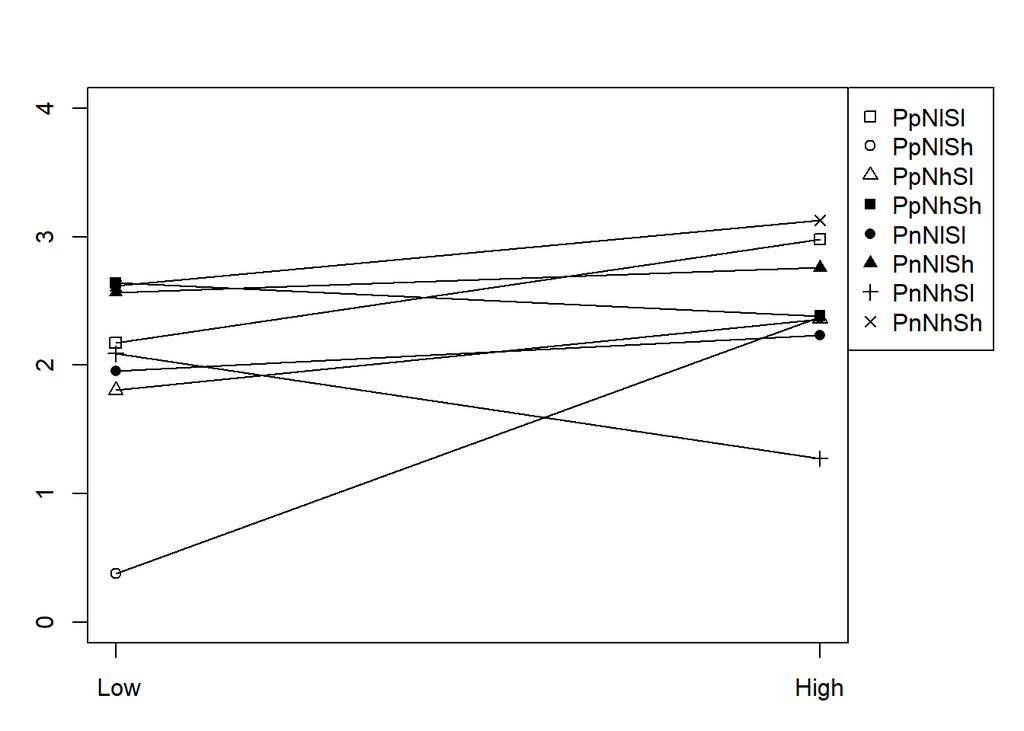

```r
x = data.frame(
    PpNlSl = c(2.176174, 2.979586),
    PpNlSh= c(0.3830053, 2.3765887),
    PpNhSl = c(1.807062, 2.360218),
    PpNhSh = c(2.63983, 2.38407),
    PnNlSl = c(1.955957, 2.233363),
    PnNlSh = c(2.567174, 2.760766),
    PnNhSl = c(2.089338, 1.274302),
    PnNhSh = c(2.618952, 3.126268)
)
par(mar=c(3,3,3,6))

plot(0, 0, type = "n", xlim = c(0, 1), ylim = range(0, 4), xlab = "Mat", ylab = "Visit", xaxt = "n")
axis(1, at=c(0, 1), formatC(c("Low", "High")))

pchs = c(0,1,2,15,16,17,3,4)

for (i in 1:ncol(x)) {
  points(0:1, x[, i], pch = pchs[i])
  lines(0:1, x[, i])
}
par(xpd=T)
legend(par()$usr[2], par()$usr[4], legend=colnames(x), pch = pchs)
```

## 単純傾斜分析3-1：非物質（プラP，物質L，スピL）

```r
model.M_PpMlsl = lm(VISIT ~ prime10 * cMAT_l * cSPI_l * cNMAT, data = ex2.data)
summary(model.M_PpMlsl)
```

```
##
## Call:
## lm(formula = VISIT ~ prime10 * cMAT_l * cSPI_l * cNMAT, data = ex2.data)
##
## Residuals:
##     Min      1Q  Median      3Q     Max
## -1.1775 -0.3609 -0.0792  0.4415  1.8732
##
## Coefficients:
##                             Estimate Std. Error t value Pr(>|t|)
## (Intercept)                  1.99163    0.24058   8.279 1.61e-10 ***
## prime10                      0.03102    0.33376   0.093  0.92638
## cMAT_l                       0.28705    0.22203   1.293  0.20282
## cSPI_l                      -0.26437    0.26928  -0.982  0.33160
## cNMAT                       -0.14982    0.21223  -0.706  0.48396
## prime10:cMAT_l              -0.40081    0.28387  -1.412  0.16499
## prime10:cSPI_l               0.57840    0.38901   1.487  0.14419
## cMAT_l:cSPI_l                0.04442    0.15314   0.290  0.77315
## prime10:cNMAT                0.20396    0.31165   0.654  0.51623
## cMAT_l:cNMAT                -0.04299    0.14901  -0.289  0.77432
## cSPI_l:cNMAT                 0.58678    0.19727   2.974  0.00475 **
## prime10:cMAT_l:cSPI_l        0.09986    0.23322   0.428  0.67060
## prime10:cMAT_l:cNMAT        -0.14467    0.21280  -0.680  0.50016
## prime10:cSPI_l:cNMAT        -0.60502    0.31257  -1.936  0.05935 .
## cMAT_l:cSPI_l:cNMAT         -0.18905    0.09247  -2.045  0.04691 *
## prime10:cMAT_l:cSPI_l:cNMAT  0.32203    0.15847   2.032  0.04821 *
## ---
## Signif. codes:  0 '***' 0.001 '**' 0.01 '*' 0.05 '.' 0.1 ' ' 1
##
## Residual standard error: 0.69 on 44 degrees of freedom
## Multiple R-squared:  0.3623, Adjusted R-squared:  0.1449
## F-statistic: 1.667 on 15 and 44 DF,  p-value: 0.09464
```

cNMAT以外の変数に0を代入すると，モデル式は $VISIT = 1.99163-0.14982\times cNMAT$ となる。この傾きは非有意。プライムP，物質L，スピLにおいて，

```r
s = sd(ex2.data$NMAT)
1.99163-0.14982 * c(-s, s)
```

```
## [1] 2.176183 1.807077
```

来談意図に差は無い。

## 単純傾斜分析3-2：非物質（プラP，物質L，スピH）

```r
model.M_PpMlsh = lm(VISIT ~ prime10 * cMAT_l * cSPI_h * cNMAT, data = ex2.data)
summary(model.M_PpMlsh)
```

```
##
## Call:
## lm(formula = VISIT ~ prime10 * cMAT_l * cSPI_h * cNMAT, data = ex2.data)
##
## Residuals:
##     Min      1Q  Median      3Q     Max
## -1.1775 -0.3609 -0.0792  0.4415  1.8732
##
## Coefficients:
##                             Estimate Std. Error t value Pr(>|t|)
## (Intercept)                  1.51141    0.44318   3.410  0.00140 **
## prime10                      1.08166    0.61885   1.748  0.08747 .
## cMAT_l                       0.36773    0.20398   1.803  0.07827 .
## cSPI_h                      -0.26437    0.26928  -0.982  0.33160
## cNMAT                        0.91605    0.29297   3.127  0.00313 **
## prime10:cMAT_l              -0.21942    0.32597  -0.673  0.50438
## prime10:cSPI_h               0.57840    0.38901   1.487  0.14419
## cMAT_l:cSPI_h                0.04442    0.15314   0.290  0.77315
## prime10:cNMAT               -0.89503    0.44813  -1.997  0.05200 .
## cMAT_l:cNMAT                -0.38640    0.12141  -3.183  0.00268 **
## cSPI_h:cNMAT                 0.58678    0.19727   2.974  0.00475 **
## prime10:cMAT_l:cSPI_h        0.09986    0.23322   0.428  0.67060
## prime10:cMAT_l:cNMAT         0.44029    0.22011   2.000  0.05166 .
## prime10:cSPI_h:cNMAT        -0.60502    0.31257  -1.936  0.05935 .
## cMAT_l:cSPI_h:cNMAT         -0.18905    0.09247  -2.045  0.04691 *
## prime10:cMAT_l:cSPI_h:cNMAT  0.32203    0.15847   2.032  0.04821 *
## ---
## Signif. codes:  0 '***' 0.001 '**' 0.01 '*' 0.05 '.' 0.1 ' ' 1
##
## Residual standard error: 0.69 on 44 degrees of freedom
## Multiple R-squared:  0.3623, Adjusted R-squared:  0.1449
## F-statistic: 1.667 on 15 and 44 DF,  p-value: 0.09464
```

cNMAT以外の変数に0を代入すると，モデル式は $VISIT = 1.51141+0.91605\times cNMAT$ となる。この傾きは有意。プライムP，物質L，スピHにおいて，

```r
s = sd(ex2.data$NMAT)
1.51141 + 0.91605 * c(-s, s)
```

```
## [1] 0.3829894 2.6398306
```

来談意図に差はある！（プライムP，物質L，スピHでは，非物資H群の方が非物資L群よりも来談意図が高い）

## 単純傾斜分析3-3：非物質（プラP，物質H，スピL）

```r
model.M_PpMhsl = lm(VISIT ~ prime10 * cMAT_h * cSPI_l * cNMAT, data = ex2.data)
summary(model.M_PpMhsl)
```

```
##
## Call:
## lm(formula = VISIT ~ prime10 * cMAT_h * cSPI_l * cNMAT, data = ex2.data)
##
## Residuals:
##     Min      1Q  Median      3Q     Max
## -1.1775 -0.3609 -0.0792  0.4415  1.8732
##
## Coefficients:
##                             Estimate Std. Error t value Pr(>|t|)
## (Intercept)                  2.66990    0.41350   6.457 7.18e-08 ***
## prime10                     -0.91607    0.59066  -1.551   0.1281
## cMAT_h                       0.28705    0.22203   1.293   0.2028
## cSPI_l                      -0.15942    0.21846  -0.730   0.4694
## cNMAT                       -0.25140    0.31568  -0.796   0.4301
## prime10:cMAT_h              -0.40081    0.28387  -1.412   0.1650
## prime10:cSPI_l               0.81436    0.37527   2.170   0.0354 *
## cMAT_h:cSPI_l                0.04442    0.15314   0.290   0.7732
## prime10:cNMAT               -0.13788    0.47030  -0.293   0.7708
## cMAT_h:cNMAT                -0.04299    0.14901  -0.289   0.7743
## cSPI_l:cNMAT                 0.14007    0.16007   0.875   0.3863
## prime10:cMAT_h:cSPI_l        0.09986    0.23322   0.428   0.6706
## prime10:cMAT_h:cNMAT        -0.14467    0.21280  -0.680   0.5002
## prime10:cSPI_l:cNMAT         0.15591    0.27491   0.567   0.5735
## cMAT_h:cSPI_l:cNMAT         -0.18905    0.09247  -2.045   0.0469 *
## prime10:cMAT_h:cSPI_l:cNMAT  0.32203    0.15847   2.032   0.0482 *
## ---
## Signif. codes:  0 '***' 0.001 '**' 0.01 '*' 0.05 '.' 0.1 ' ' 1
##
## Residual standard error: 0.69 on 44 degrees of freedom
## Multiple R-squared:  0.3623, Adjusted R-squared:  0.1449
## F-statistic: 1.667 on 15 and 44 DF,  p-value: 0.09464
```

cNMAT以外の変数に0を代入すると，モデル式は $VISIT = 2.66990-0.25140\times cNMAT$ となる。この傾きは非有意。プライムP，物質H，スピLにおいて，

```r
s = sd(ex2.data$NMAT)
2.66990-0.25140 * c(-s, s)
```

```
## [1] 2.979583 2.360217
```

来談意図に差は無い。

## 単純傾斜分析3-4：非物質（プラP，物質H，スピH）

```r
model.M_PpMhsh = lm(VISIT ~ prime10 * cMAT_h * cSPI_h * cNMAT, data = ex2.data)
summary(model.M_PpMhsh)
```

```
##
## Call:
## lm(formula = VISIT ~ prime10 * cMAT_h * cSPI_h * cNMAT, data = ex2.data)
##
## Residuals:
##     Min      1Q  Median      3Q     Max
## -1.1775 -0.3609 -0.0792  0.4415  1.8732
##
## Coefficients:
##                              Estimate Std. Error t value Pr(>|t|)
## (Intercept)                  2.380327   0.195833  12.155 1.17e-15 ***
## prime10                      0.563189   0.360990   1.560  0.12589
## cMAT_h                       0.367730   0.203978   1.803  0.07827 .
## cSPI_h                      -0.159417   0.218460  -0.730  0.46942
## cNMAT                        0.003033   0.129767   0.023  0.98146
## prime10:cMAT_h              -0.219419   0.325967  -0.673  0.50438
## prime10:cSPI_h               0.814362   0.375270   2.170  0.03544 *
## cMAT_h:cSPI_h                0.044415   0.153139   0.290  0.77315
## prime10:cNMAT                0.145324   0.246884   0.589  0.55912
## cMAT_h:cNMAT                -0.386395   0.121406  -3.183  0.00268 **
## cSPI_h:cNMAT                 0.140071   0.160070   0.875  0.38629
## prime10:cMAT_h:cSPI_h        0.099861   0.233216   0.428  0.67060
## prime10:cMAT_h:cNMAT         0.440287   0.220108   2.000  0.05166 .
## prime10:cSPI_h:cNMAT         0.155912   0.274910   0.567  0.57350
## cMAT_h:cSPI_h:cNMAT         -0.189052   0.092468  -2.045  0.04691 *
## prime10:cMAT_h:cSPI_h:cNMAT  0.322032   0.158474   2.032  0.04821 *
## ---
## Signif. codes:  0 '***' 0.001 '**' 0.01 '*' 0.05 '.' 0.1 ' ' 1
##
## Residual standard error: 0.69 on 44 degrees of freedom
## Multiple R-squared:  0.3623, Adjusted R-squared:  0.1449
## F-statistic: 1.667 on 15 and 44 DF,  p-value: 0.09464
```

cNMAT以外の変数に0を代入すると，モデル式は $VISIT = 2.380327+0.003033\times cNMAT$ となる。この傾きは非有意。プライムP，物質H，スピHにおいて，

```r
s = sd(ex2.data$NMAT)
2.380327 + 0.003033 * c(-s, s)
```

```
## [1] 2.376591 2.384063
```

来談意図に差は無い。

## 単純傾斜分析3-5：非物質（プラN，物質L，スピL）

```r
model.M_PnMlsl = lm(VISIT ~ prime01 * cMAT_l * cSPI_l * cNMAT, data = ex2.data)
summary(model.M_PnMlsl)
```

```
##
## Call:
## lm(formula = VISIT ~ prime01 * cMAT_l * cSPI_l * cNMAT, data = ex2.data)
##
## Residuals:
##     Min      1Q  Median      3Q     Max
## -1.1775 -0.3609 -0.0792  0.4415  1.8732
##
## Coefficients:
##                             Estimate Std. Error t value Pr(>|t|)
## (Intercept)                  2.02264    0.23135   8.743 3.55e-11 ***
## prime01                     -0.03102    0.33376  -0.093   0.9264
## cMAT_l                      -0.11376    0.17687  -0.643   0.5234
## cSPI_l                       0.31403    0.28074   1.119   0.2694
## cNMAT                        0.05414    0.22822   0.237   0.8136
## prime01:cMAT_l               0.40081    0.28387   1.412   0.1650
## prime01:cSPI_l              -0.57840    0.38901  -1.487   0.1442
## cMAT_l:cSPI_l                0.14428    0.17589   0.820   0.4165
## prime01:cNMAT               -0.20396    0.31165  -0.654   0.5162
## cMAT_l:cNMAT                -0.18766    0.15192  -1.235   0.2233
## cSPI_l:cNMAT                -0.01823    0.24245  -0.075   0.9404
## prime01:cMAT_l:cSPI_l       -0.09986    0.23322  -0.428   0.6706
## prime01:cMAT_l:cNMAT         0.14467    0.21280   0.680   0.5002
## prime01:cSPI_l:cNMAT         0.60502    0.31257   1.936   0.0594 .
## cMAT_l:cSPI_l:cNMAT          0.13298    0.12870   1.033   0.3071
## prime01:cMAT_l:cSPI_l:cNMAT -0.32203    0.15847  -2.032   0.0482 *
## ---
## Signif. codes:  0 '***' 0.001 '**' 0.01 '*' 0.05 '.' 0.1 ' ' 1
##
## Residual standard error: 0.69 on 44 degrees of freedom
## Multiple R-squared:  0.3623, Adjusted R-squared:  0.1449
## F-statistic: 1.667 on 15 and 44 DF,  p-value: 0.09464
```

cNMAT以外の変数に0を代入すると，モデル式は $VISIT = 2.02264 + 0.05414\times cNMAT$ となる。この傾きは非有意。プライムN，物質L，スピLにおいて，

```r
s = sd(ex2.data$NMAT)
2.02264 + 0.05414 * c(-s, s)
```

```
## [1] 1.955949 2.089331
```

来談意図に差は無い。

## 単純傾斜分析3-6：非物質（プラN，物質L，スピH）

```r
model.M_PnMlsh = lm(VISIT ~ prime01 * cMAT_l * cSPI_h * cNMAT, data = ex2.data)
summary(model.M_PnMlsh)
```

```
##
## Call:
## lm(formula = VISIT ~ prime01 * cMAT_l * cSPI_h * cNMAT, data = ex2.data)
##
## Residuals:
##     Min      1Q  Median      3Q     Max
## -1.1775 -0.3609 -0.0792  0.4415  1.8732
##
## Coefficients:
##                             Estimate Std. Error t value Pr(>|t|)
## (Intercept)                  2.59307    0.43194   6.003 3.34e-07 ***
## prime01                     -1.08166    0.61885  -1.748   0.0875 .
## cMAT_l                       0.14831    0.25426   0.583   0.5627
## cSPI_h                       0.31403    0.28074   1.119   0.2694
## cNMAT                        0.02102    0.33909   0.062   0.9509
## prime01:cMAT_l               0.21942    0.32597   0.673   0.5044
## prime01:cSPI_h              -0.57840    0.38901  -1.487   0.1442
## cMAT_l:cSPI_h                0.14428    0.17589   0.820   0.4165
## prime01:cNMAT                0.89503    0.44813   1.997   0.0520 .
## cMAT_l:cNMAT                 0.05389    0.18360   0.294   0.7705
## cSPI_h:cNMAT                -0.01823    0.24245  -0.075   0.9404
## prime01:cMAT_l:cSPI_h       -0.09986    0.23322  -0.428   0.6706
## prime01:cMAT_l:cNMAT        -0.44029    0.22011  -2.000   0.0517 .
## prime01:cSPI_h:cNMAT         0.60502    0.31257   1.936   0.0594 .
## cMAT_l:cSPI_h:cNMAT          0.13298    0.12870   1.033   0.3071
## prime01:cMAT_l:cSPI_h:cNMAT -0.32203    0.15847  -2.032   0.0482 *
## ---
## Signif. codes:  0 '***' 0.001 '**' 0.01 '*' 0.05 '.' 0.1 ' ' 1
##
## Residual standard error: 0.69 on 44 degrees of freedom
## Multiple R-squared:  0.3623, Adjusted R-squared:  0.1449
## F-statistic: 1.667 on 15 and 44 DF,  p-value: 0.09464
```

cNMAT以外の変数に0を代入すると，モデル式は $VISIT = 2.59307+0.02102\times cNMAT$ となる。この傾きは非有意。プライムN，物質L，スピHにおいて，

```r
s = sd(ex2.data$NMAT)
2.59307 + 0.02102 * c(-s, s)
```

```
## [1] 2.567177 2.618963
```

来談意図に差は無い。

## 単純傾斜分析3-7：非物質（プラN，物質H，スピL）

```r
model.M_PnMhsl = lm(VISIT ~ prime01 * cMAT_h * cSPI_l * cNMAT, data = ex2.data)
summary(model.M_PnMhsl)
```

```
##
## Call:
## lm(formula = VISIT ~ prime01 * cMAT_h * cSPI_l * cNMAT, data = ex2.data)
##
## Residuals:
##     Min      1Q  Median      3Q     Max
## -1.1775 -0.3609 -0.0792  0.4415  1.8732
##
## Coefficients:
##                             Estimate Std. Error t value Pr(>|t|)
## (Intercept)                  1.75383    0.42179   4.158 0.000146 ***
## prime01                      0.91607    0.59066   1.551 0.128086
## cMAT_h                      -0.11376    0.17687  -0.643 0.523434
## cSPI_l                       0.65495    0.30513   2.146 0.037389 *
## cNMAT                       -0.38929    0.34862  -1.117 0.270201
## prime01:cMAT_h               0.40081    0.28387   1.412 0.164993
## prime01:cSPI_l              -0.81436    0.37527  -2.170 0.035442 *
## cMAT_h:cSPI_l                0.14428    0.17589   0.820 0.416492
## prime01:cNMAT                0.13788    0.47030   0.293 0.770762
## cMAT_h:cNMAT                -0.18766    0.15192  -1.235 0.223277
## cSPI_l:cNMAT                 0.29598    0.22350   1.324 0.192241
## prime01:cMAT_h:cSPI_l       -0.09986    0.23322  -0.428 0.670600
## prime01:cMAT_h:cNMAT         0.14467    0.21280   0.680 0.500157
## prime01:cSPI_l:cNMAT        -0.15591    0.27491  -0.567 0.573502
## cMAT_h:cSPI_l:cNMAT          0.13298    0.12870   1.033 0.307135
## prime01:cMAT_h:cSPI_l:cNMAT -0.32203    0.15847  -2.032 0.048210 *
## ---
## Signif. codes:  0 '***' 0.001 '**' 0.01 '*' 0.05 '.' 0.1 ' ' 1
##
## Residual standard error: 0.69 on 44 degrees of freedom
## Multiple R-squared:  0.3623, Adjusted R-squared:  0.1449
## F-statistic: 1.667 on 15 and 44 DF,  p-value: 0.09464
```

cNMAT以外の変数に0を代入すると，モデル式は $VISIT = 1.75383 - 0.38929\times cNMAT$ となる。この傾きは非有意。プライムN，物質H，スピLにおいて，

```r
s = sd(ex2.data$NMAT)
1.75383 - 0.38929 * c(-s, s)
```

```
## [1] 2.23337 1.27429
```

来談意図に差は無い。

## 単純傾斜分析3-8：非物質（プラN，物質H，スピH）

```r
model.M_PnMhsh = lm(VISIT ~ prime01 * cMAT_h * cSPI_h * cNMAT, data = ex2.data)
summary(model.M_PnMhsh)
```

```
##
## Call:
## lm(formula = VISIT ~ prime01 * cMAT_h * cSPI_h * cNMAT, data = ex2.data)
##
## Residuals:
##     Min      1Q  Median      3Q     Max
## -1.1775 -0.3609 -0.0792  0.4415  1.8732
##
## Coefficients:
##                             Estimate Std. Error t value Pr(>|t|)
## (Intercept)                  2.94352    0.30325   9.706 1.66e-12 ***
## prime01                     -0.56319    0.36099  -1.560   0.1259
## cMAT_h                       0.14831    0.25426   0.583   0.5627
## cSPI_h                       0.65495    0.30513   2.146   0.0374 *
## cNMAT                        0.14836    0.21003   0.706   0.4837
## prime01:cMAT_h               0.21942    0.32597   0.673   0.5044
## prime01:cSPI_h              -0.81436    0.37527  -2.170   0.0354 *
## cMAT_h:cSPI_h                0.14428    0.17589   0.820   0.4165
## prime01:cNMAT               -0.14532    0.24688  -0.589   0.5591
## cMAT_h:cNMAT                 0.05389    0.18360   0.294   0.7705
## cSPI_h:cNMAT                 0.29598    0.22350   1.324   0.1922
## prime01:cMAT_h:cSPI_h       -0.09986    0.23322  -0.428   0.6706
## prime01:cMAT_h:cNMAT        -0.44029    0.22011  -2.000   0.0517 .
## prime01:cSPI_h:cNMAT        -0.15591    0.27491  -0.567   0.5735
## cMAT_h:cSPI_h:cNMAT          0.13298    0.12870   1.033   0.3071
## prime01:cMAT_h:cSPI_h:cNMAT -0.32203    0.15847  -2.032   0.0482 *
## ---
## Signif. codes:  0 '***' 0.001 '**' 0.01 '*' 0.05 '.' 0.1 ' ' 1
##
## Residual standard error: 0.69 on 44 degrees of freedom
## Multiple R-squared:  0.3623, Adjusted R-squared:  0.1449
## F-statistic: 1.667 on 15 and 44 DF,  p-value: 0.09464
```

cNMAT以外の変数に0を代入すると，モデル式は $VISIT =2.94352 + 0.14836\times cNMAT$ となる。この傾きは非有意。プライムN，物質H，スピHにおいて，

```r
s = sd(ex2.data$NMAT)
2.94352 + 0.14836 * c(-s, s)
```

```
## [1] 2.760765 3.126275
```

来談意図に差は無い。

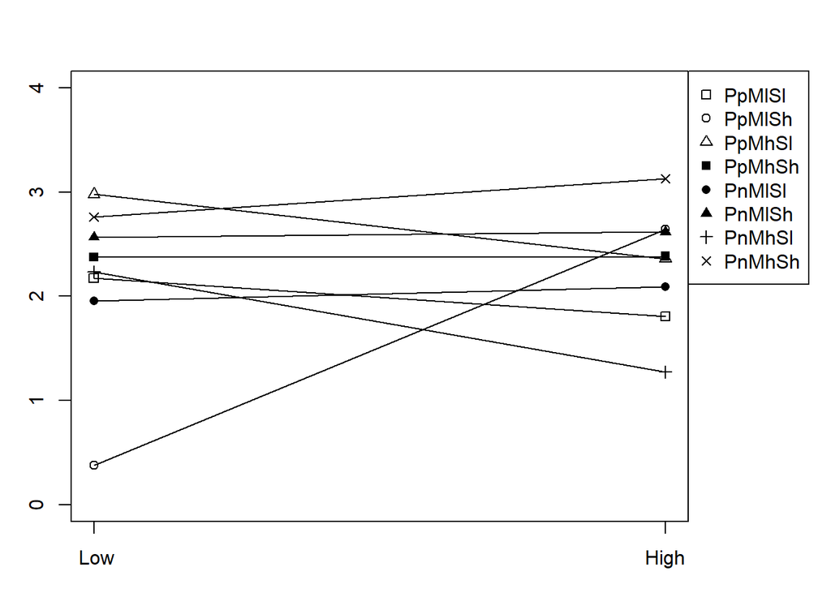

```r
x = data.frame(
    PpMlSl = c(2.176183, 1.807077),
    PpMlSh= c(0.3829894, 2.6398306),
    PpMhSl = c(2.979583, 2.360217),
    PpMhSh = c(2.376591, 2.384063),
    PnMlSl = c(1.955949, 2.089331),
    PnMlSh = c(2.567177, 2.618963),
    PnMhSl = c(2.23337, 1.27429),
    PnMhSh = c(2.760765, 3.126275)
)
par(mar=c(3,3,3,6))

plot(0, 0, type = "n", xlim = c(0, 1), ylim = range(0, 4), xlab = "Mat", ylab = "Visit", xaxt = "n")
axis(1, at=c(0, 1), formatC(c("Low", "High")))

pchs = c(0,1,2,15,16,17,3,4)

for (i in 1:ncol(x)) {
  points(0:1, x[, i], pch = pchs[i])
  lines(0:1, x[, i])
}
par(xpd=T)
legend(par()$usr[2], par()$usr[4], legend=colnames(x), pch = pchs)
```

## 単純傾斜分析4-1：スピ（プラP，物質L，非物質L）

プラPは「心理学プライム」のつもり（なので，神経科学プライムは「プラN」と表せる）。スピを最後に残す変数とするので，プラ／物質／非物質はモデル式に0を代入することになる。これから行おうとする分析は，「心理学プライム条件」に固定するので，心理学プライム条件が0で表されるダミー変数prime10を使わなければならない点に注意。

```r
model.S_PpMlNl = lm(VISIT ~ prime10 * cMAT_l * cNMAT_l * cSPI, data = ex2.data)
summary(model.S_PpMlNl)
```

```
##
## Call:
## lm(formula = VISIT ~ prime10 * cMAT_l * cNMAT_l * cSPI, data = ex2.data)
##
## Residuals:
##     Min      1Q  Median      3Q     Max
## -1.1775 -0.3609 -0.0792  0.4415  1.8732
##
## Coefficients:
##                             Estimate Std. Error t value Pr(>|t|)
## (Intercept)                  1.27959    0.42428   3.016  0.00424 **
## prime10                      0.98198    0.56473   1.739  0.08906 .
## cMAT_l                       0.59186    0.25849   2.290  0.02689 *
## cNMAT_l                      0.38311    0.18258   2.098  0.04165 *
## cSPI                        -0.98719    0.41137  -2.400  0.02071 *
## prime10:cMAT_l              -0.49219    0.34082  -1.444  0.15579
## prime10:cNMAT_l             -0.34554    0.26150  -1.321  0.19321
## cMAT_l:cNMAT_l              -0.21469    0.10686  -2.009  0.05068 .
## prime10:cSPI                 1.32368    0.60661   2.182  0.03449 *
## cMAT_l:cSPI                  0.27730    0.21136   1.312  0.19633
## cNMAT_l:cSPI                 0.58678    0.19727   2.974  0.00475 **
## prime10:cMAT_l:cNMAT_l       0.14781    0.16171   0.914  0.36567
## prime10:cMAT_l:cSPI         -0.29683    0.34149  -0.869  0.38944
## prime10:cNMAT_l:cSPI        -0.60502    0.31257  -1.936  0.05935 .
## cMAT_l:cNMAT_l:cSPI         -0.18905    0.09247  -2.045  0.04691 *
## prime10:cMAT_l:cNMAT_l:cSPI  0.32203    0.15847   2.032  0.04821 *
## ---
## Signif. codes:  0 '***' 0.001 '**' 0.01 '*' 0.05 '.' 0.1 ' ' 1
##
## Residual standard error: 0.69 on 44 degrees of freedom
## Multiple R-squared:  0.3623, Adjusted R-squared:  0.1449
## F-statistic: 1.667 on 15 and 44 DF,  p-value: 0.09464
```

cSPI以外の変数に0を代入すると，モデル式は $VISIT = 1.27959 - 0.98719\times cSPI$ となる。この傾きは有意。プライムP，物質L，非物質Lにおいて，

```r
s = sd(ex2.data$SPI)
1.27959 - 0.98719 * c(-s, s)
```

```
## [1] 2.1761856 0.3829944
```

前者がスピL群，後者がスピH群の参照値（グラフ作成で使う値）となる。 来談意図に差はある！（プライムP，物質L，非物質Lでは，スピL群の方がスピH群よりも来談意図が高い）

## 単純傾斜分析4-2：スピ（プラP，物質L，非物質H）

```r
model.S_PpMlNh = lm(VISIT ~ prime10 * cMAT_l * cNMAT_h * cSPI, data = ex2.data)
summary(model.S_PpMlNh)
```

```
##
## Call:
## lm(formula = VISIT ~ prime10 * cMAT_l * cNMAT_h * cSPI, data = ex2.data)
##
## Residuals:
##     Min      1Q  Median      3Q     Max
## -1.1775 -0.3609 -0.0792  0.4415  1.8732
##
## Coefficients:
##                             Estimate Std. Error t value Pr(>|t|)
## (Intercept)                  2.22345    0.23626   9.411  4.2e-12 ***
## prime10                      0.13069    0.36514   0.358  0.72211
## cMAT_l                       0.06293    0.14161   0.444  0.65895
## cNMAT_h                      0.38311    0.18258   2.098  0.04165 *
## cSPI                         0.45845    0.30644   1.496  0.14178
## prime10:cMAT_l              -0.12804    0.24556  -0.521  0.60469
## prime10:cNMAT_h             -0.34554    0.26150  -1.321  0.19321
## cMAT_l:cNMAT_h              -0.21469    0.10686  -2.009  0.05068 .
## prime10:cSPI                -0.16688    0.48080  -0.347  0.73018
## cMAT_l:cSPI                 -0.18847    0.16787  -1.123  0.26766
## cNMAT_h:cSPI                 0.58678    0.19727   2.974  0.00475 **
## prime10:cMAT_l:cNMAT_h       0.14781    0.16171   0.914  0.36567
## prime10:cMAT_l:cSPI          0.49655    0.26150   1.899  0.06416 .
## prime10:cNMAT_h:cSPI        -0.60502    0.31257  -1.936  0.05935 .
## cMAT_l:cNMAT_h:cSPI         -0.18905    0.09247  -2.045  0.04691 *
## prime10:cMAT_l:cNMAT_h:cSPI  0.32203    0.15847   2.032  0.04821 *
## ---
## Signif. codes:  0 '***' 0.001 '**' 0.01 '*' 0.05 '.' 0.1 ' ' 1
##
## Residual standard error: 0.69 on 44 degrees of freedom
## Multiple R-squared:  0.3623, Adjusted R-squared:  0.1449
## F-statistic: 1.667 on 15 and 44 DF,  p-value: 0.09464
```

cSPI以外の変数に0を代入すると，モデル式は $VISIT = 2.22345 +0.45845\times cSPI$ となる。この傾きは非有意。プライムP，物質L，非物質Hにおいて，

```r
s = sd(ex2.data$SPI)
2.22345+0.45845 * c(-s, s)
```

```
## [1] 1.807072 2.639828
```

来談意図に差は無い。

## 単純傾斜分析4-3：スピ（プラP，物質H，非物質L）

```r
model.S_PpMhNl = lm(VISIT ~ prime10 * cMAT_h * cNMAT_l * cSPI, data = ex2.data)
summary(model.S_PpMhNl)
```

```
##
## Call:
## lm(formula = VISIT ~ prime10 * cMAT_h * cNMAT_l * cSPI, data = ex2.data)
##
## Residuals:
##     Min      1Q  Median      3Q     Max
## -1.1775 -0.3609 -0.0792  0.4415  1.8732
##
## Coefficients:
##                             Estimate Std. Error t value Pr(>|t|)
## (Intercept)                  2.67809    0.43439   6.165 1.93e-07 ***
## prime10                     -0.18102    0.51269  -0.353   0.7257
## cMAT_h                       0.59186    0.25849   2.290   0.0269 *
## cNMAT_l                     -0.12418    0.19264  -0.645   0.5225
## cSPI                        -0.33196    0.34767  -0.955   0.3449
## prime10:cMAT_h              -0.49219    0.34082  -1.444   0.1558
## prime10:cNMAT_l              0.00372    0.28058   0.013   0.9895
## cMAT_h:cNMAT_l              -0.21469    0.10686  -2.009   0.0507 .
## prime10:cSPI                 0.62230    0.55507   1.121   0.2683
## cMAT_h:cSPI                  0.27730    0.21136   1.312   0.1963
## cNMAT_l:cSPI                 0.14007    0.16007   0.875   0.3863
## prime10:cMAT_h:cNMAT_l       0.14781    0.16171   0.914   0.3657
## prime10:cMAT_h:cSPI         -0.29683    0.34148  -0.869   0.3894
## prime10:cNMAT_l:cSPI         0.15591    0.27491   0.567   0.5735
## cMAT_h:cNMAT_l:cSPI         -0.18905    0.09247  -2.045   0.0469 *
## prime10:cMAT_h:cNMAT_l:cSPI  0.32203    0.15847   2.032   0.0482 *
## ---
## Signif. codes:  0 '***' 0.001 '**' 0.01 '*' 0.05 '.' 0.1 ' ' 1
##
## Residual standard error: 0.69 on 44 degrees of freedom
## Multiple R-squared:  0.3623, Adjusted R-squared:  0.1449
## F-statistic: 1.667 on 15 and 44 DF,  p-value: 0.09464
```

cSPI以外の変数に0を代入すると，モデル式は $VISIT = 2.67809-0.33196\times cSPI$ となる。この傾きは非有意。プライムP，物質H，非物質Lにおいて，

```r
s = sd(ex2.data$SPI)
2.67809-0.33196 * c(-s, s)
```

```
## [1] 2.979586 2.376594
```

来談意図に差は無い。

## 単純傾斜分析4-4：スピ（プラP，物質H，非物質H）

```r
model.S_PpMhNh = lm(VISIT ~ prime10 * cMAT_h * cNMAT_h * cSPI, data = ex2.data)
summary(model.S_PpMhNh)
```

```
##
## Call:
## lm(formula = VISIT ~ prime10 * cMAT_h * cNMAT_h * cSPI, data = ex2.data)
##
## Residuals:
##     Min      1Q  Median      3Q     Max
## -1.1775 -0.3609 -0.0792  0.4415  1.8732
##
## Coefficients:
##                             Estimate Std. Error t value Pr(>|t|)
## (Intercept)                  2.37214    0.23352  10.158 4.11e-13 ***
## prime10                     -0.17186    0.47216  -0.364   0.7176
## cMAT_h                       0.06293    0.14161   0.444   0.6590
## cNMAT_h                     -0.12418    0.19264  -0.645   0.5225
## cSPI                         0.01313    0.22876   0.057   0.9545
## prime10:cMAT_h              -0.12804    0.24556  -0.521   0.6047
## prime10:cNMAT_h              0.00372    0.28058   0.013   0.9895
## cMAT_h:cNMAT_h              -0.21469    0.10686  -2.009   0.0507 .
## prime10:cSPI                 1.00642    0.45045   2.234   0.0306 *
## cMAT_h:cSPI                 -0.18846    0.16787  -1.123   0.2677
## cNMAT_h:cSPI                 0.14007    0.16007   0.875   0.3863
## prime10:cMAT_h:cNMAT_h       0.14781    0.16171   0.914   0.3657
## prime10:cMAT_h:cSPI          0.49655    0.26150   1.899   0.0642 .
## prime10:cNMAT_h:cSPI         0.15591    0.27491   0.567   0.5735
## cMAT_h:cNMAT_h:cSPI         -0.18905    0.09247  -2.045   0.0469 *
## prime10:cMAT_h:cNMAT_h:cSPI  0.32203    0.15847   2.032   0.0482 *
## ---
## Signif. codes:  0 '***' 0.001 '**' 0.01 '*' 0.05 '.' 0.1 ' ' 1
##
## Residual standard error: 0.69 on 44 degrees of freedom
## Multiple R-squared:  0.3623, Adjusted R-squared:  0.1449
## F-statistic: 1.667 on 15 and 44 DF,  p-value: 0.09464
```

cSPI以外の変数に0を代入すると，モデル式は $VISIT = 2.37214 + 0.01313\times cSPI$ となる。この傾きは非有意。プライムP，物質H，非物質Hにおいて，

```r
s = sd(ex2.data$SPI)
2.37214 + 0.01313 * c(-s, s)
```

```
## [1] 2.360215 2.384065
```

来談意図に差は無い。

## 単純傾斜分析4-5：スピ（プラN，物質L，非物質L）

```r
model.S_PnMlNl = lm(VISIT ~ prime01 * cMAT_l * cNMAT_l * cSPI, data = ex2.data)
summary(model.S_PnMlNl)
```

```
##
## Call:
## lm(formula = VISIT ~ prime01 * cMAT_l * cNMAT_l * cSPI, data = ex2.data)
##
## Residuals:
##     Min      1Q  Median      3Q     Max
## -1.1775 -0.3609 -0.0792  0.4415  1.8732
##
## Coefficients:
##                             Estimate Std. Error t value Pr(>|t|)
## (Intercept)                  2.26157    0.37271   6.068 2.68e-07 ***
## prime01                     -0.98198    0.56473  -1.739   0.0891 .
## cMAT_l                       0.09967    0.22213   0.449   0.6559
## cNMAT_l                      0.03758    0.18721   0.201   0.8418
## cSPI                         0.33650    0.44582   0.755   0.4544
## prime01:cMAT_l               0.49219    0.34082   1.444   0.1558
## prime01:cNMAT_l              0.34554    0.26150   1.321   0.1932
## cMAT_l:cNMAT_l              -0.06688    0.12137  -0.551   0.5844
## prime01:cSPI                -1.32368    0.60661  -2.182   0.0345 *
## cMAT_l:cSPI                 -0.01953    0.26822  -0.073   0.9423
## cNMAT_l:cSPI                -0.01823    0.24245  -0.075   0.9404
## prime01:cMAT_l:cNMAT_l      -0.14781    0.16171  -0.914   0.3657
## prime01:cMAT_l:cSPI          0.29683    0.34149   0.869   0.3894
## prime01:cNMAT_l:cSPI         0.60502    0.31257   1.936   0.0594 .
## cMAT_l:cNMAT_l:cSPI          0.13298    0.12870   1.033   0.3071
## prime01:cMAT_l:cNMAT_l:cSPI -0.32203    0.15847  -2.032   0.0482 *
## ---
## Signif. codes:  0 '***' 0.001 '**' 0.01 '*' 0.05 '.' 0.1 ' ' 1
##
## Residual standard error: 0.69 on 44 degrees of freedom
## Multiple R-squared:  0.3623, Adjusted R-squared:  0.1449
## F-statistic: 1.667 on 15 and 44 DF,  p-value: 0.09464
```

cSPI以外の変数に0を代入すると，モデル式は $VISIT = 2.26157 + 0.33650\times cSPI$ となる。この傾きは非有意。プライムN，物質L，非物質Lにおいて，

```r
s = sd(ex2.data$SPI)
2.26157 + 0.33650 * c(-s, s)
```

```
## [1] 1.955951 2.567189
```

来談意図に差は無い。

## 単純傾斜分析4-6：スピ（プラN，物質L，非物質H）

```r
model.S_PnMlNh = lm(VISIT ~ prime01 * cMAT_l * cNMAT_h * cSPI, data = ex2.data)
summary(model.S_PnMlNh)
```

```
##
## Call:
## lm(formula = VISIT ~ prime01 * cMAT_l * cNMAT_h * cSPI, data = ex2.data)
##
## Residuals:
##     Min      1Q  Median      3Q     Max
## -1.1775 -0.3609 -0.0792  0.4415  1.8732
##
## Coefficients:
##                             Estimate Std. Error t value Pr(>|t|)
## (Intercept)                  2.35415    0.27840   8.456 9.02e-11 ***
## prime01                     -0.13069    0.36514  -0.358   0.7221
## cMAT_l                      -0.06512    0.20062  -0.325   0.7470
## cNMAT_h                      0.03758    0.18721   0.201   0.8418
## cSPI                         0.29157    0.37049   0.787   0.4355
## prime01:cMAT_l               0.12804    0.24556   0.521   0.6047
## prime01:cNMAT_h              0.34554    0.26150   1.321   0.1932
## cMAT_l:cNMAT_h              -0.06688    0.12137  -0.551   0.5844
## prime01:cSPI                 0.16688    0.48080   0.347   0.7302
## cMAT_l:cSPI                  0.30809    0.20051   1.537   0.1316
## cNMAT_h:cSPI                -0.01823    0.24245  -0.075   0.9404
## prime01:cMAT_l:cNMAT_h      -0.14781    0.16171  -0.914   0.3657
## prime01:cMAT_l:cSPI         -0.49655    0.26150  -1.899   0.0642 .
## prime01:cNMAT_h:cSPI         0.60502    0.31257   1.936   0.0594 .
## cMAT_l:cNMAT_h:cSPI          0.13298    0.12870   1.033   0.3071
## prime01:cMAT_l:cNMAT_h:cSPI -0.32203    0.15847  -2.032   0.0482 *
## ---
## Signif. codes:  0 '***' 0.001 '**' 0.01 '*' 0.05 '.' 0.1 ' ' 1
##
## Residual standard error: 0.69 on 44 degrees of freedom
## Multiple R-squared:  0.3623, Adjusted R-squared:  0.1449
## F-statistic: 1.667 on 15 and 44 DF,  p-value: 0.09464
```

cSPI以外の変数に0を代入すると，モデル式は $VISIT = 2.35415 + 0.29157\times cSPI$ となる。この傾きは非有意。プライムN，物質L，非物質Hにおいて，

```r
s = sd(ex2.data$SPI)
2.35415 + 0.29157 * c(-s, s)
```

```
## [1] 2.089337 2.618963
```

来談意図に差は無い。

## 単純傾斜分析4-7：スピ（プラN，物質H，非物質L）

```r
model.S_PnMhNl = lm(VISIT ~ prime01 * cMAT_h * cNMAT_l * cSPI, data = ex2.data)
summary(model.S_PnMhNl)
```

```
##
## Call:
## lm(formula = VISIT ~ prime01 * cMAT_h * cNMAT_l * cSPI, data = ex2.data)
##
## Residuals:
##     Min      1Q  Median      3Q     Max
## -1.1775 -0.3609 -0.0792  0.4415  1.8732
##
## Coefficients:
##                             Estimate Std. Error t value Pr(>|t|)
## (Intercept)                  2.49707    0.27233   9.169 9.04e-12 ***
## prime01                      0.18102    0.51269   0.353   0.7257
## cMAT_h                       0.09967    0.22213   0.449   0.6559
## cNMAT_l                     -0.12046    0.20400  -0.591   0.5579
## cSPI                         0.29034    0.43270   0.671   0.5057
## prime01:cMAT_h               0.49219    0.34082   1.444   0.1558
## prime01:cNMAT_l             -0.00372    0.28058  -0.013   0.9895
## cMAT_h:cNMAT_l              -0.06688    0.12137  -0.551   0.5844
## prime01:cSPI                -0.62230    0.55507  -1.121   0.2683
## cMAT_h:cSPI                 -0.01953    0.26822  -0.073   0.9423
## cNMAT_l:cSPI                 0.29598    0.22350   1.324   0.1922
## prime01:cMAT_h:cNMAT_l      -0.14781    0.16171  -0.914   0.3657
## prime01:cMAT_h:cSPI          0.29683    0.34148   0.869   0.3894
## prime01:cNMAT_l:cSPI        -0.15591    0.27491  -0.567   0.5735
## cMAT_h:cNMAT_l:cSPI          0.13298    0.12870   1.033   0.3071
## prime01:cMAT_h:cNMAT_l:cSPI -0.32203    0.15847  -2.032   0.0482 *
## ---
## Signif. codes:  0 '***' 0.001 '**' 0.01 '*' 0.05 '.' 0.1 ' ' 1
##
## Residual standard error: 0.69 on 44 degrees of freedom
## Multiple R-squared:  0.3623, Adjusted R-squared:  0.1449
## F-statistic: 1.667 on 15 and 44 DF,  p-value: 0.09464
```

cSPI以外の変数に0を代入すると，モデル式は $VISIT = 2.49707 + 0.29034\times cSPI$ となる。この傾きは非有意。プライムN，物質H，非物質Lにおいて，

```r
s = sd(ex2.data$SPI)
2.49707 + 0.29034 * c(-s, s)
```

```
## [1] 2.233374 2.760766
```

来談意図に差は無い。

## 単純傾斜分析4-8：スピ（プラN，物質H，非物質H）

```r
model.S_PnMhNh = lm(VISIT ~ prime01 * cMAT_h * cNMAT_h * cSPI, data = ex2.data)
summary(model.S_PnMhNh)
```

```
##
## Call:
## lm(formula = VISIT ~ prime01 * cMAT_h * cNMAT_h * cSPI, data = ex2.data)
##
## Residuals:
##     Min      1Q  Median      3Q     Max
## -1.1775 -0.3609 -0.0792  0.4415  1.8732
##
## Coefficients:
##                             Estimate Std. Error t value Pr(>|t|)
## (Intercept)                  2.20028    0.41037   5.362  2.9e-06 ***
## prime01                      0.17186    0.47216   0.364   0.7176
## cMAT_h                      -0.06512    0.20062  -0.325   0.7470
## cNMAT_h                     -0.12046    0.20400  -0.591   0.5579
## cSPI                         1.01955    0.38804   2.627   0.0118 *
## prime01:cMAT_h               0.12804    0.24556   0.521   0.6047
## prime01:cNMAT_h             -0.00372    0.28058  -0.013   0.9895
## cMAT_h:cNMAT_h              -0.06688    0.12137  -0.551   0.5844
## prime01:cSPI                -1.00642    0.45045  -2.234   0.0306 *
## cMAT_h:cSPI                  0.30808    0.20051   1.537   0.1316
## cNMAT_h:cSPI                 0.29598    0.22350   1.324   0.1922
## prime01:cMAT_h:cNMAT_h      -0.14781    0.16171  -0.914   0.3657
## prime01:cMAT_h:cSPI         -0.49655    0.26150  -1.899   0.0642 .
## prime01:cNMAT_h:cSPI        -0.15591    0.27491  -0.567   0.5735
## cMAT_h:cNMAT_h:cSPI          0.13298    0.12870   1.033   0.3071
## prime01:cMAT_h:cNMAT_h:cSPI -0.32203    0.15847  -2.032   0.0482 *
## ---
## Signif. codes:  0 '***' 0.001 '**' 0.01 '*' 0.05 '.' 0.1 ' ' 1
##
## Residual standard error: 0.69 on 44 degrees of freedom
## Multiple R-squared:  0.3623, Adjusted R-squared:  0.1449
## F-statistic: 1.667 on 15 and 44 DF,  p-value: 0.09464
```

cSPI以外の変数に0を代入すると，モデル式は $VISIT = 2.20028 + 1.01955\times cSPI$ となる。この傾きは有意。プライムN，物質H，非物質Hにおいて，

```r
s = sd(ex2.data$SPI)
2.20028 + 1.01955 * c(-s, s)
```

```
## [1] 1.274294 3.126266
```

来談意図に差はある！（プライムN，物質H，非物質Hでは，スピH群の方がスピL群よりも来談意図が高い）

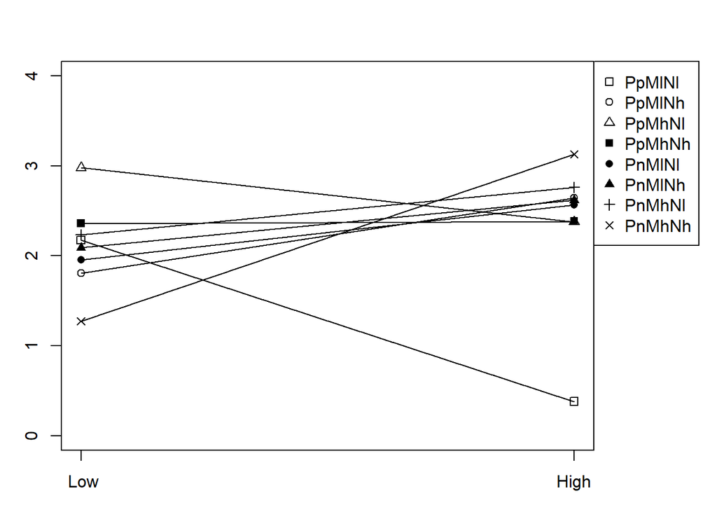

```r
x = data.frame(
    PpMlNl = c(2.1761856, 0.3829944),
    PpMlNh= c(1.807072, 2.639828),
    PpMhNl = c(2.979586, 2.376594),
    PpMhNh = c(2.360215, 2.384065),
    PnMlNl = c(1.955951, 2.567189),
    PnMlNh = c(2.089337, 2.618963),
    PnMhNl = c(2.233374, 2.760766),
    PnMhNh = c(1.274294, 3.126266)
)
par(mar=c(3,3,3,6))

plot(0, 0, type = "n", xlim = c(0, 1), ylim = range(0, 4), xlab = "Mat", ylab = "Visit", xaxt = "n")
axis(1, at=c(0, 1), formatC(c("Low", "High")))

pchs = c(0,1,2,15,16,17,3,4)

for (i in 1:ncol(x)) {
  points(0:1, x[, i], pch = pchs[i])
  lines(0:1, x[, i])
}
par(xpd=T)
legend(par()$usr[2], par()$usr[4], legend=colnames(x), pch = pchs)
```